# Association

Function to extract statistics

```r
library(survival)
library(broom)
library(dplyr)

# Enhanced function to fit Cox model and extract statistics, including CI calculation
fit_and_extract_cox <- function(formula, data, model_name) {
  model <- coxph(formula, data)
  tidy_model <- broom::tidy(model)

  # Calculate Hazard Ratios and Confidence Intervals
  tidy_model <- tidy_model %>%
    mutate(HR = exp(estimate),
           lower_CI = exp(estimate - 1.96 * std.error),
           upper_CI = exp(estimate + 1.96 * std.error),
           model_identifier = model_name)

  return(tidy_model)
}
```

Multiple models

```r
formulas <- list(ADRD1 = Surv(AgeAtFirstDate, AgeAtLastDate, ADRD) ~ kdm_res + gender,
                 ADRD2 = Surv(AgeAtFirstDate, AgeAtLastDate, ADRD) ~ phenoage_res + gender,
                 ADRD3 = Surv(AgeAtFirstDate, AgeAtLastDate, ADRD) ~ hd_log_res + gender,
                 ADRD4 = Surv(AgeAtFirstDate, AgeAtLastDate, ADRD) ~ phenoage_res + kdm_res + gender,
                 ADRD5 = Surv(AgeAtFirstDate, AgeAtLastDate, ADRD) ~ kdm_res+ age + gender + BMI + NewUtbNiva + income_bins,
                 ADRD6 = Surv(AgeAtFirstDate, AgeAtLastDate, ADRD) ~ phenoage_res + age + gender + BMI + NewUtbNiva + income_bins,
                 ADRD7 = Surv(AgeAtFirstDate, AgeAtLastDate, ADRD) ~ hd_log_res + age + gender + BMI + NewUtbNiva + income_bins,
                 ADRD8 = Surv(AgeAtFirstDate, AgeAtLastDate, ADRD) ~ phenoage_res + kdm_res + age + gender + BMI + NewUtbNiva + income_bins,
                 ADRD9 = Surv(AgeAtFirstDate, AgeAtLastDate, ADRD) ~ kdm_res + gender + income_bins,
                 ADRD10 = Surv(AgeAtFirstDate, AgeAtLastDate, ADRD) ~ phenoage_res + gender + income_bins,
                 ADRD11 = Surv(AgeAtFirstDate, AgeAtLastDate, ADRD) ~ hd_log_res + gender + income_bins,
                 ADRD12 = Surv(AgeAtFirstDate, AgeAtLastDate, ADRD) ~  phenoage_res + kdm_res + gender + income_bins,
                 Alzh1 = Surv(AgeAtFirstDate, AgeAtLastDate, Alzheimers) ~ kdm_res + gender,
                 Alzh2 = Surv(AgeAtFirstDate, AgeAtLastDate, Alzheimers) ~ phenoage_res + gender,
                 Alzh3 = Surv(AgeAtFirstDate, AgeAtLastDate, Alzheimers) ~ hd_log_res + gender,
                 Alzh4 = Surv(AgeAtFirstDate, AgeAtLastDate, Alzheimers) ~ phenoage_res + kdm_res + gender,
                 Alzh5 = Surv(AgeAtFirstDate, AgeAtLastDate, Alzheimers) ~ kdm_res + age + gender + BMI + NewUtbNiva + income_bins,
                 Alzh6 = Surv(AgeAtFirstDate, AgeAtLastDate, Alzheimers) ~ phenoage_res + age + gender + BMI + NewUtbNiva + income_bins,
                 Alzh7 = Surv(AgeAtFirstDate, AgeAtLastDate, Alzheimers) ~ hd_log_res + age + gender + BMI + NewUtbNiva + income_bins,
                 Alzh8 = Surv(AgeAtFirstDate, AgeAtLastDate, Alzheimers) ~ phenoage_res + kdm_res + age + gender + BMI + NewUtbNiva + income_bins,
                 Alzh9 = Surv(AgeAtFirstDate, AgeAtLastDate, Alzheimers) ~ kdm_res + gender + income_bins,
                 Alzh10 = Surv(AgeAtFirstDate, AgeAtLastDate, Alzheimers) ~ phenoage_res + gender + income_bins,
                 Alzh11 = Surv(AgeAtFirstDate, AgeAtLastDate, Alzheimers) ~ hd_log_res + gender + income_bins,
                 Alzh12 = Surv(AgeAtFirstDate, AgeAtLastDate, Alzheimers) ~ phenoage_res + kdm_res + gender + income_bins,
                 Vasc1 = Surv(AgeAtFirstDate, AgeAtLastDate, Vascular) ~ kdm_res + gender,
                 Vasc2 = Surv(AgeAtFirstDate, AgeAtLastDate, Vascular) ~ phenoage_res + gender,
                 Vasc3 = Surv(AgeAtFirstDate, AgeAtLastDate, Vascular) ~ hd_log_res + gender,
                 Vasc4 = Surv(AgeAtFirstDate, AgeAtLastDate, Vascular) ~ phenoage_res + kdm_res + gender,
                 Vasc5 = Surv(AgeAtFirstDate, AgeAtLastDate, Vascular) ~ kdm_res + age + gender + BMI + NewUtbNiva + income_bins,
                 Vasc6 = Surv(AgeAtFirstDate, AgeAtLastDate, Vascular) ~ phenoage_res + age + gender + BMI + NewUtbNiva + income_bins,
                 Vasc7 = Surv(AgeAtFirstDate, AgeAtLastDate, Vascular) ~ hd_log_res + age + gender + BMI + NewUtbNiva + income_bins,
                 Vasc8 = Surv(AgeAtFirstDate, AgeAtLastDate, Vascular) ~ phenoage_res + kdm_res + age + gender + BMI + NewUtbNiva + income_bins,
                 Vasc9 = Surv(AgeAtFirstDate, AgeAtLastDate, Vascular) ~ kdm_res + gender + income_bins,
                 Vasc10 = Surv(AgeAtFirstDate, AgeAtLastDate, Vascular) ~ phenoage_res + gender + income_bins,
                 Vasc11 = Surv(AgeAtFirstDate, AgeAtLastDate, Vascular) ~ hd_log_res + gender + income_bins,
                 Vasc12 = Surv(AgeAtFirstDate, AgeAtLastDate, Vascular) ~ phenoage_res + kdm_res + gender + income_bins,
                 Othe1 = Surv(AgeAtFirstDate, AgeAtLastDate, Other) ~ kdm_res + gender,
                 Othe2 = Surv(AgeAtFirstDate, AgeAtLastDate, Other) ~ phenoage_res + gender,
                 Othe3 = Surv(AgeAtFirstDate, AgeAtLastDate, Other) ~ hd_log_res + gender,
                 Othe4 = Surv(AgeAtFirstDate, AgeAtLastDate, Other) ~ phenoage_res + kdm_res + gender,
                 Othe5 = Surv(AgeAtFirstDate, AgeAtLastDate, Other) ~ kdm_res + age + gender + BMI + NewUtbNiva + income_bins,
                 Othe6 = Surv(AgeAtFirstDate, AgeAtLastDate, Other) ~ phenoage_res + age + gender + BMI + NewUtbNiva + income_bins,
                 Othe7 = Surv(AgeAtFirstDate, AgeAtLastDate, Other) ~ hd_log_res + age + gender + BMI + NewUtbNiva + income_bins,
                 Othe8 = Surv(AgeAtFirstDate, AgeAtLastDate, Other) ~ phenoage_res + kdm_res + age + gender + BMI + NewUtbNiva + income_bins,
                 Othe9 = Surv(AgeAtFirstDate, AgeAtLastDate, Other) ~ kdm_res + gender + income_bins,
                 Othe10 = Surv(AgeAtFirstDate, AgeAtLastDate, Other) ~ phenoage_res + gender + income_bins,
                 Othe11 = Surv(AgeAtFirstDate, AgeAtLastDate, Other) ~ hd_log_res + gender + income_bins,
                 Othe12 = Surv(AgeAtFirstDate, AgeAtLastDate, Other) ~ phenoage_res + kdm_res + gender + income_bins)
```

Applying it

```r
results <- lapply(names(formulas), function(name) {
  fit_and_extract_cox(formulas[[name]], to1po2, name)
})
# Combine results into a single data frame
final_results <- do.call(rbind, results)

# View the final results
print(final_results)
```

| term | estimate | std.error | statistic | p.value | HR | lower_CI | upper_CI | model_identifier |
| --- | --- | --- | --- | --- | --- | --- | --- | --- |
| kdm_res | 1.302353e-02 | 2.215883e-03 | 5.877353504 | 4.168774e-09 | 1.013109e+00 | 1.0087182 | 1.0175183 | ADRD1 |
| gender2 | 5.365650e-02 | 1.411774e-02 | 3.800645024 | 1.443199e-04 | 1.055122e+00 | 1.0263263 | 1.0847258 | ADRD1 |
| phenoage_res | 4.459248e-02 | 2.704298e-03 | 16.489485499 | 4.366518e-61 | 1.045602e+00 | 1.0400742 | 1.0511585 | ADRD2 |
| gender2 | 5.406721e-02 | 1.374903e-02 | 3.932437103 | 8.408899e-05 | 1.055556e+00 | 1.0274902 | 1.0843875 | ADRD2 |
| hd_log_res | 8.952621e-02 | 6.797129e-03 | 13.171181156 | 1.285703e-39 | 1.093656e+00 | 1.0791825 | 1.1083236 | ADRD3 |
| gender2 | 3.506497e-02 | 1.372686e-02 | 2.554479176 | 1.063468e-02 | 1.035687e+00 | 1.0081937 | 1.0639300 | ADRD3 |
| phenoage_res | 4.733069e-02 | 2.829653e-03 | 16.726676109 | 8.378551e-63 | 1.048469e+00 | 1.0426698 | 1.0542998 | ADRD4 |
| kdm_res | 8.706790e-03 | 2.199133e-03 | 3.959191811 | 7.520382e-05 | 1.008745e+00 | 1.0044062 | 1.0131022 | ADRD4 |
| gender2 | 6.491303e-02 | 1.413813e-02 | 4.591344902 | 4.403989e-06 | 1.067066e+00 | 1.0379030 | 1.0970489 | ADRD4 |
| kdm_res | -1.171453e-02 | 1.550581e-02 | -0.755493078 | 4.499532e-01 | 9.883538e-01 | 0.9587682 | 1.0188524 | ADRD5 |

[output cut: 226 more lines]

```r
### now for global stats about the models

library(survival)
library(broom)
library(dplyr)

fit_and_extract_cox <- function(formula, data, model_name) {
  # Fit the Cox model
  model <- coxph(formula, data = data)

  # Get the summary of the model
  model_summary <- summary(model)

  # Extract global model statistics
  global_stats <- list(
    log_rank_test = model_summary$logtest, # Log-rank test (part of summary)
    wald_test = model_summary$waldtest,    # Wald test (part of summary)
    likelihood_ratio_test = model_summary$sctest, # Likelihood ratio test (part of summary)
    concordance_index = concordance(model)$concordance # Updated concordance function
  )

  # Return a list containing both covariate and global statistics
  list(covariates = broom::tidy(model), global = global_stats, model_identifier = model_name)
}

# Apply the function to each model
results <- lapply(names(formulas), function(name) {
  fit_and_extract_cox(formulas[[name]], to1po2, name) # Use to1po2 instead of your_data
})
# Now we want it in a better output format
library(dplyr)

# Step 1: Extract and combine covariate-level results
#covariate_results <- lapply(results, function(model_result) {
#  model_covariates <- model_result$covariates
#  model_covariates$model_identifier <- model_result$model_identifier
#  return(model_covariates)
#})
#covariate_results_df <- do.call(rbind, covariate_results)
covariate_results <- lapply(results, function(model_result) {
  model_covariates <- model_result$covariates %>%
    mutate(HR = exp(estimate),
           lower_CI = exp(estimate - 1.96 * std.error),
           upper_CI = exp(estimate + 1.96 * std.error))
  model_covariates$model_identifier <- model_result$model_identifier
  return(model_covariates)
})
covariate_results_df <- do.call(rbind, covariate_results)

# Step 2: Extract and combine global model statistics
# Adjusted Step 2: Extract and reformat global model statistics
global_results <- lapply(results, function(model_result) {
  model_globals <- model_result$global
  data.frame(
    model_identifier = model_result$model_identifier,
    log_rank_test_stat = model_globals$log_rank_test["test"],
    log_rank_test_pvalue = model_globals$log_rank_test["pvalue"],
    wald_test_stat = model_globals$wald_test["test"],
    wald_test_pvalue = model_globals$wald_test["pvalue"],
    likelihood_ratio_test_stat = model_globals$likelihood_ratio_test["test"],
    likelihood_ratio_test_pvalue = model_globals$likelihood_ratio_test["pvalue"],
    concordance_index = model_globals$concordance_index
  )
})
global_results_df <- do.call(rbind, global_results)

# Step 3: Merge covariate-level and global statistics
final_results_df <- merge(covariate_results_df, global_results_df, by = "model_identifier")

# View the final combined results
print(final_results_df)
```

| model_identifier | term | estimate | std.error | statistic | p.value | HR | lower_CI | upper_CI | log_rank_test_stat | log_rank_test_pvalue | wald_test_stat | wald_test_pvalue | likelihood_ratio_test_stat | likelihood_ratio_test_pvalue | concordance_index |
| --- | --- | --- | --- | --- | --- | --- | --- | --- | --- | --- | --- | --- | --- | --- | --- |
| ADRD1 | kdm_res | 1.302353e-02 | 2.215883e-03 | 5.877353504 | 4.168774e-09 | 1.013109e+00 | 1.0087182 | 1.0175183 | 46.730487 | 7.122030e-11 | 47.23 | 5.557793e-11 | 47.223420 | 5.566275e-11 | 0.5106543 |
| ADRD1 | gender2 | 5.365650e-02 | 1.411774e-02 | 3.800645024 | 1.443199e-04 | 1.055122e+00 | 1.0263263 | 1.0847258 | 46.730487 | 7.122030e-11 | 47.23 | 5.557793e-11 | 47.223420 | 5.566275e-11 | 0.5106543 |
| ADRD10 | phenoage_res | 3.660595e-02 | 5.795371e-03 | 6.316411810 | 2.677061e-10 | 1.037284e+00 | 1.0255684 | 1.0491338 | 48.772309 | 6.513651e-10 | 49.36 | 4.910260e-10 | 49.347828 | 4.940233e-10 | 0.5447843 |
| ADRD10 | gender2 | 3.120094e-02 | 3.180561e-02 | 0.980988739 | 3.265983e-01 | 1.031693e+00 | 0.9693417 | 1.0980544 | 48.772309 | 6.513651e-10 | 49.36 | 4.910260e-10 | 49.347828 | 4.940233e-10 | 0.5447843 |
| ADRD10 | income_binsLow Income | -8.706707e-03 | 5.322101e-02 | -0.163595309 | 8.700497e-01 | 9.913311e-01 | 0.8931329 | 1.1003260 | 48.772309 | 6.513651e-10 | 49.36 | 4.910260e-10 | 49.347828 | 4.940233e-10 | 0.5447843 |
| ADRD10 | income_binsHigh Income | -1.141782e-01 | 4.693266e-02 | -2.432808839 | 1.498221e-02 | 8.920990e-01 | 0.8136978 | 0.9780542 | 48.772309 | 6.513651e-10 | 49.36 | 4.910260e-10 | 49.347828 | 4.940233e-10 | 0.5447843 |
| ADRD11 | hd_log_res | 8.376452e-02 | 1.454855e-02 | 5.757585239 | 8.532569e-09 | 1.087373e+00 | 1.0568041 | 1.1188257 | 42.831098 | 1.121746e-08 | 42.64 | 1.226890e-08 | 42.646683 | 1.225038e-08 | 0.5396967 |
| ADRD11 | gender2 | 1.163787e-02 | 3.171446e-02 | 0.366957832 | 7.136505e-01 | 1.011706e+00 | 0.9507326 | 1.0765895 | 42.831098 | 1.121746e-08 | 42.64 | 1.226890e-08 | 42.646683 | 1.225038e-08 | 0.5396967 |
| ADRD11 | income_binsLow Income | -9.725673e-03 | 5.321996e-02 | -0.182744851 | 8.549982e-01 | 9.903215e-01 | 0.8922251 | 1.0992031 | 42.831098 | 1.121746e-08 | 42.64 | 1.226890e-08 | 42.646683 | 1.225038e-08 | 0.5396967 |
| ADRD11 | income_binsHigh Income | -1.235424e-01 | 4.689036e-02 | -2.634708838 | 8.420948e-03 | 8.837841e-01 | 0.8061806 | 0.9688579 | 42.831098 | 1.121746e-08 | 42.64 | 1.226890e-08 | 42.646683 | 1.225038e-08 | 0.5396967 |

[output cut: 226 more lines]

Shoenfield residuals for each covariate BA variables are key here

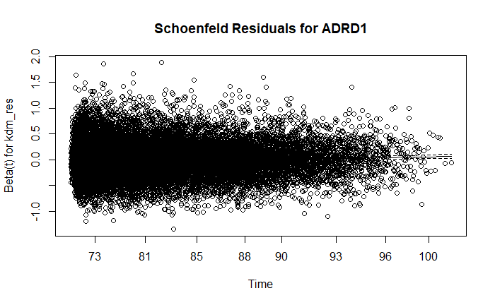

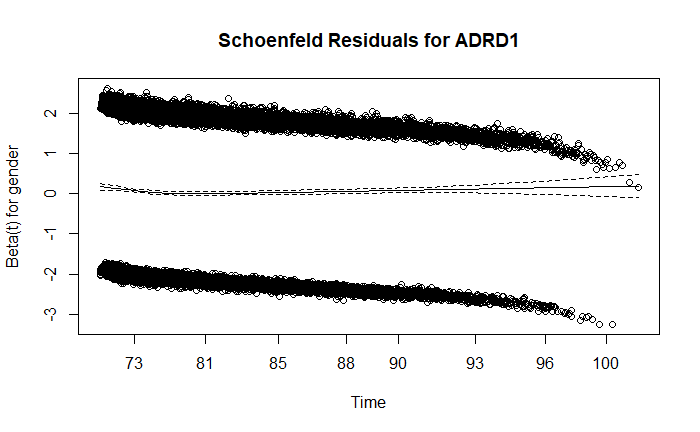

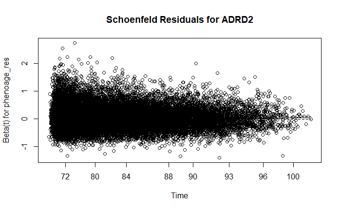

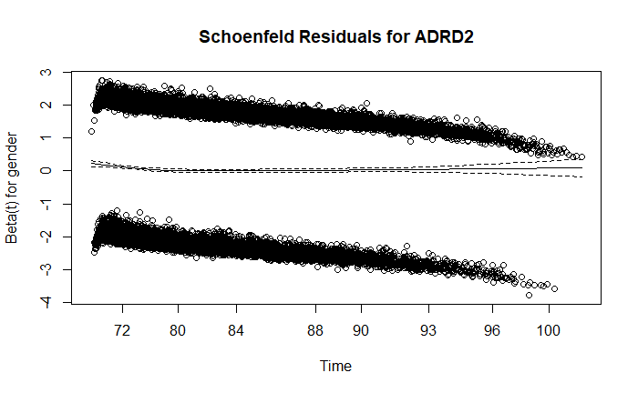

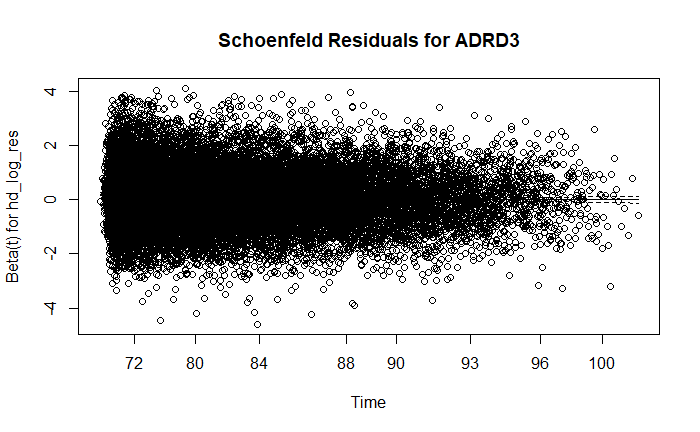

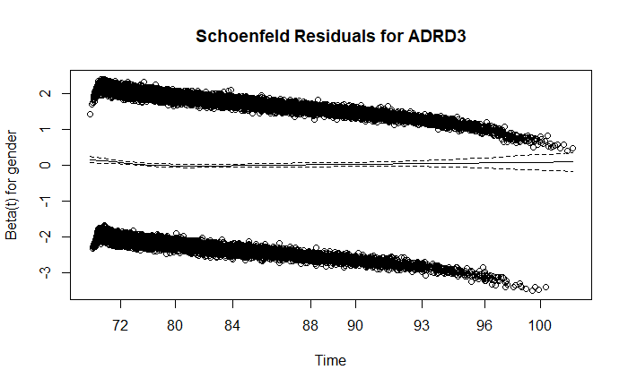

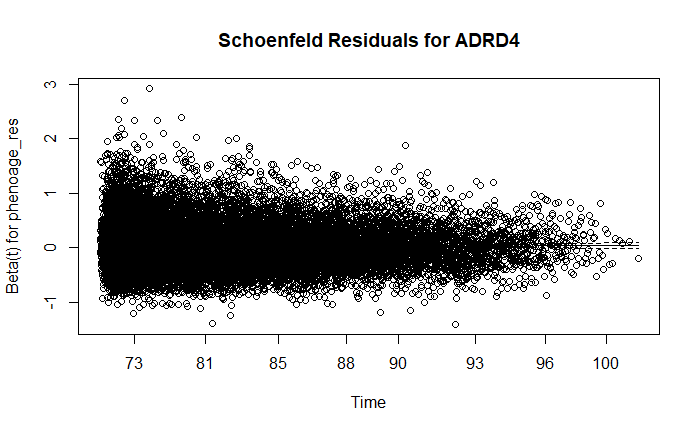

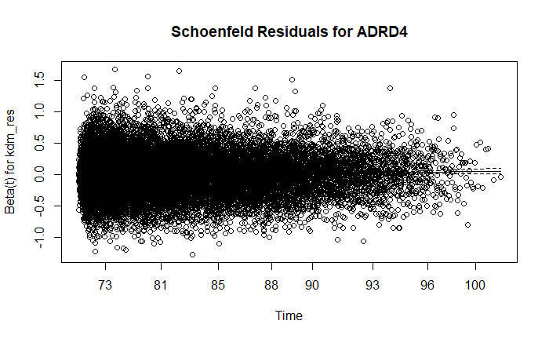

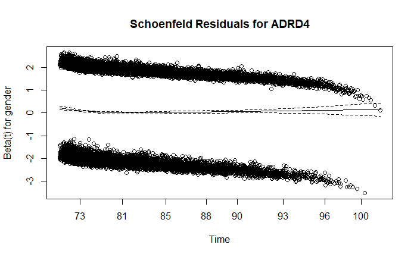

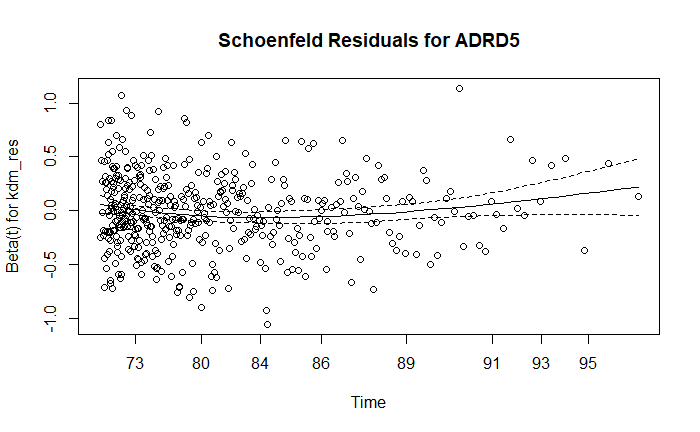

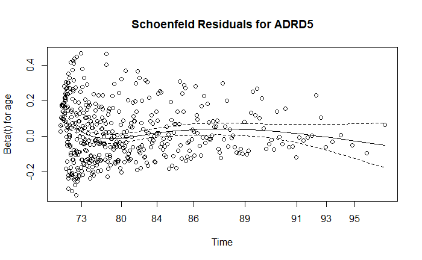

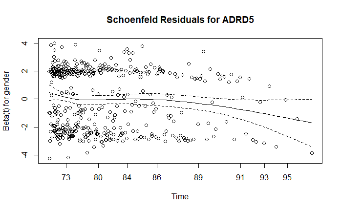

[176 more figures not shown]

```r
# Fit each Cox model and store them in a new list
fitted_models <- lapply(formulas, function(fml) {
  coxph(fml, data = to1po2)
})
# Function to plot Schoenfeld residuals for a given model
plot_schoenfeld <- function(fitted_model, model_name) {
  schoenfeld_res <- cox.zph(fitted_model)
  plot(schoenfeld_res, main = paste("Schoenfeld Residuals for", model_name))
}

# Iterate over the fitted models and plot Schoenfeld residuals for each model
names(fitted_models) <- names(formulas)
lapply(names(fitted_models), function(model_name) {
  plot_schoenfeld(fitted_models[[model_name]], model_name)
})
```

Cox.zph global stats

```r
zph_results <- lapply(fitted_models, cox.zph)

# Function to extract key statistics from cox.zph result
extract_zph_stats <- function(zph_result, model_name) {
  # Ensure zph_result is a cox.zph object
  if (!inherits(zph_result, "cox.zph")) {
    stop("Input is not a valid cox.zph object")
  }

  # Extracting statistics for each covariate including GLOBAL
  covariate_stats <- as.data.frame(zph_result$table)
  covariate_stats$Variable <- rownames(covariate_stats)
  rownames(covariate_stats) <- NULL  # Remove row names
  covariate_stats$Model <- model_name

  return(covariate_stats)
}

# Apply the function to each zph result
model_names <- names(fitted_models)
all_stats <- mapply(extract_zph_stats, zph_results, model_names, SIMPLIFY = FALSE)

# Combine all statistics into a single data frame
combined_stats_df <- do.call(rbind, all_stats)

# Optional: Arrange and format for better readability
formatted_stats_df <- combined_stats_df %>%
  arrange(Model, Variable) %>%
  select(Model, Variable, everything())  # Rearrange columns if needed
```

```r
# Extract and combine global test statistics into a single data frame
global_stats_df <- do.call(rbind, lapply(all_stats, function(model_stats) {
  filter(model_stats, Variable == "GLOBAL")
}))

# Optionally, arrange and format for better readability
global_stats_df <- global_stats_df %>%
  arrange(Model) %>%
  select(Model, everything())
```

Stratifying

```r
formulas_strat <- list(stratADRD_all_kdm = Surv(AgeAtFirstDate, AgeAtLastDate, ADRD) ~ kdm_res+ strata(income_bins, NewUtbNiva, is_woman, is_man, under_sixtyfive, over_sixtyfive),
                 stratADRD_all_phe = Surv(AgeAtFirstDate, AgeAtLastDate, ADRD) ~ phenoage_res + strata(income_bins, NewUtbNiva, is_woman, is_man, under_sixtyfive, over_sixtyfive),
                 stratADRD_all_hd = Surv(AgeAtFirstDate, AgeAtLastDate, ADRD) ~ hd_log_res + strata(income_bins, NewUtbNiva, is_woman, is_man, under_sixtyfive, over_sixtyfive),
                 stratADRD_all_phe_kdm = Surv(AgeAtFirstDate, AgeAtLastDate, ADRD) ~ phenoage_res + kdm_res + strata(income_bins, NewUtbNiva, is_woman, is_man, under_sixtyfive, over_sixtyfive),
                 stratAlzh_all_kdm = Surv(AgeAtFirstDate, AgeAtLastDate, Alzheimers) ~ kdm_res+ strata(income_bins, NewUtbNiva, is_woman, is_man, under_sixtyfive, over_sixtyfive),
                 stratAlzh_all_phe = Surv(AgeAtFirstDate, AgeAtLastDate, Alzheimers) ~ phenoage_res + strata(income_bins, NewUtbNiva, is_woman, is_man, under_sixtyfive, over_sixtyfive),
                 stratAlzh_all_hd = Surv(AgeAtFirstDate, AgeAtLastDate, Alzheimers) ~ hd_log_res + strata(income_bins, NewUtbNiva, is_woman, is_man, under_sixtyfive, over_sixtyfive),
                 stratAlzh_all_phe_kdm = Surv(AgeAtFirstDate, AgeAtLastDate, Alzheimers) ~ phenoage_res + kdm_res + strata(income_bins, NewUtbNiva, is_woman, is_man, under_sixtyfive, over_sixtyfive),
                 stratVasc_all_kdm = Surv(AgeAtFirstDate, AgeAtLastDate, Vascular) ~ kdm_res+ strata(income_bins, NewUtbNiva, is_woman, is_man, under_sixtyfive, over_sixtyfive),
                 stratVasc_all_phe = Surv(AgeAtFirstDate, AgeAtLastDate, Vascular) ~ phenoage_res + strata(income_bins, NewUtbNiva, is_woman, is_man, under_sixtyfive, over_sixtyfive),
                 stratVasc_all_hd = Surv(AgeAtFirstDate, AgeAtLastDate, Vascular) ~ hd_log_res + strata(income_bins, NewUtbNiva, is_woman, is_man, under_sixtyfive, over_sixtyfive),
                 stratVasc_all_phe_kdm = Surv(AgeAtFirstDate, AgeAtLastDate, Vascular) ~ phenoage_res + kdm_res + strata(income_bins, NewUtbNiva, is_woman, is_man, under_sixtyfive, over_sixtyfive),
                 stratOthe_all_kdm = Surv(AgeAtFirstDate, AgeAtLastDate, Other) ~ kdm_res+ strata(income_bins, NewUtbNiva, is_woman, is_man, under_sixtyfive, over_sixtyfive),
                 stratOthe_all_phe = Surv(AgeAtFirstDate, AgeAtLastDate, Other) ~ phenoage_res + strata(income_bins, NewUtbNiva, is_woman, is_man, under_sixtyfive, over_sixtyfive),
                 stratOthe_all_hd = Surv(AgeAtFirstDate, AgeAtLastDate, Other) ~ hd_log_res + strata(income_bins, NewUtbNiva, is_woman, is_man, under_sixtyfive, over_sixtyfive),
                 stratOthe_all_phe_kdm = Surv(AgeAtFirstDate, AgeAtLastDate, Other) ~ phenoage_res + kdm_res + strata(income_bins, NewUtbNiva, is_woman, is_man, under_sixtyfive, over_sixtyfive)
                 )
```

Get output in a not ideal format

```r
# Initialize lists to store results
model_summaries <- list()
model_zph_tests <- list()
model_concordance_indices <- list()

# Loop through each formula and fit models
for(model_name in names(formulas_strat)) {
    # Fit Cox model
    cox_model <- coxph(formulas_strat[[model_name]], to1po2)

    # Store model summary
    model_summaries[[model_name]] <- summary(cox_model)

    # Perform and store cox.zph test result
    model_zph_tests[[model_name]] <- cox.zph(cox_model)

    # Calculate and store concordance index
    model_concordance_indices[[model_name]] <- concordance(cox_model)$concordance
}

# Output the results
print(model_summaries)
print(model_zph_tests)
print(model_concordance_indices)
```

[output not shown]

#======== Let’s make it less messy The first part is inspired by J’s Code

ADRD

```r
# BA measures to be tested
BA_measures <- c("kdm_res", "phenoage_res", "hd_log_res")

# Correct the initialization of HR_BA data frame
HR_BA_adrd <- data.frame(
  BA = rep(BA_measures, each = 2),  # Repeat each BA measure twice
  outcome = rep("ADRD", times = length(BA_measures) * 2),
  model = rep(c("Sex-adjusted model", "Multivariable model"), times = length(BA_measures)),
  beta = NA, se = NA, HR = NA, lb = NA, ub = NA, p = NA, p_PH_BA = NA, global_p_PH_BA = NA,
  concordance = NA, N = NA  # Add a column for the concordance index
)

for (j in 1:length(BA_measures)) {
  # Sex-adjusted model
  fit_gender <- coxph(as.formula(paste("Surv(AgeAtFirstDate, AgeAtLastDate, ADRD) ~", BA_measures[j], "+ gender")), data = to1po2)
  coef_gender <- summary(fit_gender)
  row_index_gender <- (j * 2) - 1
  HR_BA_adrd[row_index_gender, c(4, 5, 9, 12)] <- c(coef_gender$coefficients[1, c(1, 3, 5)], coef_gender$concordance[1])
  HR_BA_adrd[row_index_gender, 6:8] <- coef_gender$conf.int[1, c(1, 3, 4)]
  HR_BA_adrd[row_index_gender, 10] <- cox.zph(fit_gender)$table[1, 3]
  HR_BA_adrd[row_index_gender, 11] <- cox.zph(fit_gender)$table[3, 3]
  HR_BA_adrd[row_index_gender, "N"] <- coef_gender$n

  # Multivariable model
  fit_multivariable <- coxph(as.formula(paste("Surv(AgeAtFirstDate, AgeAtLastDate, ADRD) ~", BA_measures[j], "+ gender + income_bins + NewUtbNiva")), data = to1po2)
  coef_multivariable <- summary(fit_multivariable)
  row_index_multivariable <- j * 2
  HR_BA_adrd[row_index_multivariable, c(4, 5, 9, 12)] <- c(coef_multivariable$coefficients[1, c(1, 3, 5)], coef_multivariable$concordance[1])
  HR_BA_adrd[row_index_multivariable, 6:8] <- coef_multivariable$conf.int[1, c(1, 3, 4)]
  HR_BA_adrd[row_index_multivariable, 10] <- cox.zph(fit_multivariable)$table[1, 3]
  HR_BA_adrd[row_index_multivariable, 11] <- cox.zph(fit_multivariable)$table[3, 3]
  HR_BA_adrd[row_index_multivariable, "N"] <- coef_multivariable$n
}

ADRD_results <- HR_BA_adrd

# Print the modified HR_BA_adrd data frame
print(HR_BA_adrd)
```

| BA | outcome | model | beta | se | HR | lb | ub | p | p_PH_BA | global_p_PH_BA | concordance | N |
| --- | --- | --- | --- | --- | --- | --- | --- | --- | --- | --- | --- | --- |
| kdm_res | ADRD | Sex-adjusted model | 0.013700449 | 0.001608884 | 1.013795 | 1.010603 | 1.016997 | 1.658731e-17 | 4.133423e-01 | 6.987565e-01 | 0.5104451 | 231742 |
| kdm_res | ADRD | Multivariable model | 0.009549484 | 0.003475805 | 1.009595 | 1.002741 | 1.016497 | 6.006684e-03 | 3.640601e-03 | 2.389475e-02 | 0.5427759 | 59539 |
| phenoage_res | ADRD | Sex-adjusted model | 0.038185240 | 0.002459800 | 1.038924 | 1.033927 | 1.043945 | 2.397417e-54 | 6.226792e-13 | 1.022362e-13 | 0.5377877 | 259810 |
| phenoage_res | ADRD | Multivariable model | 0.026523031 | 0.005318638 | 1.026878 | 1.016229 | 1.037638 | 6.138462e-07 | 2.530103e-03 | 2.478114e-02 | 0.5464453 | 67376 |
| hd_log_res | ADRD | Sex-adjusted model | 0.093113285 | 0.006836323 | 1.097586 | 1.082978 | 1.112392 | 3.030058e-42 | 4.953763e-10 | 1.884979e-09 | 0.5332593 | 259810 |
| hd_log_res | ADRD | Multivariable model | 0.078973516 | 0.014683731 | 1.082176 | 1.051475 | 1.113773 | 7.519224e-08 | 1.857238e-03 | 2.342379e-02 | 0.5456021 | 67376 |

ADRD based on SveDem

```r
# BA measures to be tested
BA_measures <- c("kdm_res", "phenoage_res", "hd_log_res")

# Correct the initialization of HR_BA_adrd data frame
HR_BA_s_adrd <- data.frame(
  BA = rep(BA_measures, each = 2),  # Repeat each BA measure twice
  outcome = rep("SveDem ADRD", times = length(BA_measures) * 2),
  model = rep(c("Sex-adjusted model", "Multivariable model"), times = length(BA_measures)),
  beta = NA, se = NA, HR = NA, lb = NA, ub = NA, p = NA, p_PH_BA = NA, global_p_PH_BA = NA,
  concordance = NA, N=NA  # Add a column for the concordance index
)

for (j in 1:length(BA_measures)) {
  # Sex-adjusted model
  fit_gender <- coxph(as.formula(paste("Surv(AgeAtFirstDate, AgeAtLastDate, S_ADRD_all) ~", BA_measures[j], "+ gender")), data = to1po2)
  coef_gender <- summary(fit_gender)
  row_index_gender <- (j * 2) - 1
  HR_BA_s_adrd[row_index_gender, c(4, 5, 9, 12)] <- c(coef_gender$coefficients[1, c(1, 3, 5)], coef_gender$concordance[1])
  HR_BA_s_adrd[row_index_gender, 6:8] <- coef_gender$conf.int[1, c(1, 3, 4)]
  HR_BA_s_adrd[row_index_gender, 10] <- cox.zph(fit_gender)$table[1, 3]
  HR_BA_s_adrd[row_index_gender, 11] <- cox.zph(fit_gender)$table[3, 3]
  HR_BA_s_adrd[row_index_gender, "N"] <- coef_gender$n

  # Multivariable model
  fit_multivariable <- coxph(as.formula(paste("Surv(AgeAtFirstDate, AgeAtLastDate, S_ADRD_all) ~", BA_measures[j], "+ gender + income_bins + NewUtbNiva")), data = to1po2)
  coef_multivariable <- summary(fit_multivariable)
  row_index_multivariable <- j * 2
  HR_BA_s_adrd[row_index_multivariable, c(4, 5, 9, 12)] <- c(coef_multivariable$coefficients[1, c(1, 3, 5)], coef_multivariable$concordance[1])
  HR_BA_s_adrd[row_index_multivariable, 6:8] <- coef_multivariable$conf.int[1, c(1, 3, 4)]
  HR_BA_s_adrd[row_index_multivariable, 10] <- cox.zph(fit_multivariable)$table[1, 3]
  HR_BA_s_adrd[row_index_multivariable, 11] <- cox.zph(fit_multivariable)$table[3, 3]
  HR_BA_s_adrd[row_index_multivariable, "N"] <- coef_multivariable$n
}

S_ADRD_results <- HR_BA_s_adrd

# Print the modified HR_BA_adrd data frame
print(HR_BA_s_adrd)
```

| BA | outcome | model | beta | se | HR | lb | ub | p | p_PH_BA | global_p_PH_BA | concordance | N |
| --- | --- | --- | --- | --- | --- | --- | --- | --- | --- | --- | --- | --- |
| kdm_res | SveDem ADRD | Sex-adjusted model | 0.013234359 | 0.002770154 | 1.013322 | 1.0078355 | 1.018839 | 1.775052e-06 | 2.984511e-01 | 4.171655e-01 | 0.5151835 | 231742 |
| kdm_res | SveDem ADRD | Multivariable model | 0.009383461 | 0.005793993 | 1.009428 | 0.9980294 | 1.020956 | 1.053364e-01 | 2.299410e-02 | 8.183526e-01 | 0.5303412 | 59539 |
| phenoage_res | SveDem ADRD | Sex-adjusted model | 0.009385498 | 0.004501031 | 1.009430 | 1.0005638 | 1.018374 | 3.705221e-02 | 2.263107e-06 | 4.449632e-08 | 0.5155978 | 259810 |
| phenoage_res | SveDem ADRD | Multivariable model | 0.013186704 | 0.009519741 | 1.013274 | 0.9945433 | 1.032358 | 1.659926e-01 | 3.866875e-03 | 4.351367e-01 | 0.5379656 | 67376 |
| hd_log_res | SveDem ADRD | Sex-adjusted model | 0.058412717 | 0.012256363 | 1.060152 | 1.0349889 | 1.085928 | 1.880035e-06 | 2.633584e-02 | 2.221301e-03 | 0.5215301 | 259810 |
| hd_log_res | SveDem ADRD | Multivariable model | 0.081730766 | 0.025935336 | 1.085164 | 1.0313808 | 1.141751 | 1.625296e-03 | 1.821411e-01 | 4.233048e-01 | 0.5391675 | 67376 |

Alzheimers broad category ie not SveDem

```r
# BA measures to be tested
BA_measures <- c("kdm_res", "phenoage_res", "hd_log_res")

# Correct the initialization of HR_BA_adrd data frame
HR_BA_alzh <- data.frame(
  BA = rep(BA_measures, each = 2),  # Repeat each BA measure twice
  outcome = rep("Alzheimers", times = length(BA_measures) * 2),
  model = rep(c("Sex-adjusted model", "Multivariable model"), times = length(BA_measures)),
  beta = NA, se = NA, HR = NA, lb = NA, ub = NA, p = NA, p_PH_BA = NA, global_p_PH_BA = NA,
  concordance = NA, N=NA  # Add a column for the concordance index
)

for (j in 1:length(BA_measures)) {
  # Sex-adjusted model
  fit_gender <- coxph(as.formula(paste("Surv(AgeAtFirstDate, AgeAtLastDate, Alzheimers) ~", BA_measures[j], "+ gender")), data = to1po2)
  coef_gender <- summary(fit_gender)
  row_index_gender <- (j * 2) - 1
  HR_BA_alzh[row_index_gender, c(4, 5, 9, 12)] <- c(coef_gender$coefficients[1, c(1, 3, 5)], coef_gender$concordance[1])
  HR_BA_alzh[row_index_gender, 6:8] <- coef_gender$conf.int[1, c(1, 3, 4)]
  HR_BA_alzh[row_index_gender, 10] <- cox.zph(fit_gender)$table[1, 3]
  HR_BA_alzh[row_index_gender, 11] <- cox.zph(fit_gender)$table[3, 3]
  HR_BA_alzh[row_index_gender, "N"] <- coef_gender$n

  # Multivariable model
  fit_multivariable <- coxph(as.formula(paste("Surv(AgeAtFirstDate, AgeAtLastDate, Alzheimers) ~", BA_measures[j], "+ gender + income_bins + NewUtbNiva")), data = to1po2)
  coef_multivariable <- summary(fit_multivariable)
  row_index_multivariable <- j * 2
  HR_BA_alzh[row_index_multivariable, c(4, 5, 9, 12)] <- c(coef_multivariable$coefficients[1, c(1, 3, 5)], coef_multivariable$concordance[1])
  HR_BA_alzh[row_index_multivariable, 6:8] <- coef_multivariable$conf.int[1, c(1, 3, 4)]
  HR_BA_alzh[row_index_multivariable, 10] <- cox.zph(fit_multivariable)$table[1, 3]
  HR_BA_alzh[row_index_multivariable, 11] <- cox.zph(fit_multivariable)$table[3, 3]
  HR_BA_alzh[row_index_multivariable, "N"] <- coef_multivariable$n
}

Alzh_results <- HR_BA_alzh

# Print the modified HR_BA_adrd data frame
print(HR_BA_alzh)
```

| BA | outcome | model | beta | se | HR | lb | ub | p | p_PH_BA | global_p_PH_BA | concordance | N |
| --- | --- | --- | --- | --- | --- | --- | --- | --- | --- | --- | --- | --- |
| kdm_res | Alzheimers | Sex-adjusted model | 0.0100420285 | 0.002484586 | 1.0100926 | 1.0051857 | 1.015023 | 5.305796e-05 | 0.14612285 | 3.765181e-03 | 0.5336307 | 231742 |
| kdm_res | Alzheimers | Multivariable model | 0.0065179863 | 0.005363652 | 1.0065393 | 0.9960134 | 1.017176 | 2.242844e-01 | 0.05293122 | 1.416171e-01 | 0.5371557 | 59539 |
| phenoage_res | Alzheimers | Sex-adjusted model | -0.0019706875 | 0.004070485 | 0.9980313 | 0.9901006 | 1.006025 | 6.282861e-01 | 0.02320734 | 1.558998e-05 | 0.5266146 | 259810 |
| phenoage_res | Alzheimers | Multivariable model | 0.0006942037 | 0.008750557 | 1.0006944 | 0.9836781 | 1.018005 | 9.367681e-01 | 0.57179698 | 9.717377e-02 | 0.5300967 | 67376 |
| hd_log_res | Alzheimers | Sex-adjusted model | 0.0127607831 | 0.011032554 | 1.0128425 | 0.9911765 | 1.034982 | 2.474161e-01 | 0.24629027 | 3.395286e-04 | 0.5304046 | 259810 |
| hd_log_res | Alzheimers | Multivariable model | 0.0126689340 | 0.023746710 | 1.0127495 | 0.9666935 | 1.061000 | 5.936856e-01 | 0.56512183 | 9.585823e-02 | 0.5312389 | 67376 |

SveDem Alzheimers

```r
# BA measures to be tested
BA_measures <- c("kdm_res", "phenoage_res", "hd_log_res")

# Correct the initialization of HR_BA_adrd data frame
HR_BA_s_alzh <- data.frame(
  BA = rep(BA_measures, each = 2),  # Repeat each BA measure twice
  outcome = rep("SveDem Alzheimers", times = length(BA_measures) * 2),
  model = rep(c("Sex-adjusted model", "Multivariable model"), times = length(BA_measures)),
  beta = NA, se = NA, HR = NA, lb = NA, ub = NA, p = NA, p_PH_BA = NA, global_p_PH_BA = NA,
  concordance = NA, N=NA  # Add a column for the concordance index
)

for (j in 1:length(BA_measures)) {
  # Sex-adjusted model
  fit_gender <- coxph(as.formula(paste("Surv(AgeAtFirstDate, AgeAtLastDate, S_Alzheimers_all) ~", BA_measures[j], "+ gender")), data = to1po2)
  coef_gender <- summary(fit_gender)
  row_index_gender <- (j * 2) - 1
  HR_BA_s_alzh[row_index_gender, c(4, 5, 9, 12)] <- c(coef_gender$coefficients[1, c(1, 3, 5)], coef_gender$concordance[1])
  HR_BA_s_alzh[row_index_gender, 6:8] <- coef_gender$conf.int[1, c(1, 3, 4)]
  HR_BA_s_alzh[row_index_gender, 10] <- cox.zph(fit_gender)$table[1, 3]
  HR_BA_s_alzh[row_index_gender, 11] <- cox.zph(fit_gender)$table[3, 3]
  HR_BA_s_alzh[row_index_gender, "N"] <- coef_gender$n

  # Multivariable model
  fit_multivariable <- coxph(as.formula(paste("Surv(AgeAtFirstDate, AgeAtLastDate, S_Alzheimers_all) ~", BA_measures[j], "+ gender + income_bins + NewUtbNiva")), data = to1po2)
  coef_multivariable <- summary(fit_multivariable)
  row_index_multivariable <- j * 2
  HR_BA_s_alzh[row_index_multivariable, c(4, 5, 9, 12)] <- c(coef_multivariable$coefficients[1, c(1, 3, 5)], coef_multivariable$concordance[1])
  HR_BA_s_alzh[row_index_multivariable, 6:8] <- coef_multivariable$conf.int[1, c(1, 3, 4)]
  HR_BA_s_alzh[row_index_multivariable, 10] <- cox.zph(fit_multivariable)$table[1, 3]
  HR_BA_s_alzh[row_index_multivariable, 11] <- cox.zph(fit_multivariable)$table[3, 3]
  HR_BA_s_alzh[row_index_multivariable, "N"] <- coef_multivariable$n
}

S_Alzh_results <- HR_BA_s_alzh

# Print the modified HR_BA_adrd data frame
print(HR_BA_s_alzh)
```

| BA | outcome | model | beta | se | HR | lb | ub | p | p_PH_BA | global_p_PH_BA | concordance | N |
| --- | --- | --- | --- | --- | --- | --- | --- | --- | --- | --- | --- | --- |
| kdm_res | SveDem Alzheimers | Sex-adjusted model | 0.0116299203 | 0.003503036 | 1.0116978 | 1.0047755 | 1.0186679 | 0.0009003211 | 0.14667340 | 2.634747e-03 | 0.5384160 | 231742 |
| kdm_res | SveDem Alzheimers | Multivariable model | 0.0054798961 | 0.007431119 | 1.0054949 | 0.9909563 | 1.0202469 | 0.4608636503 | 0.06228812 | 5.309320e-01 | 0.5545602 | 59539 |
| phenoage_res | SveDem Alzheimers | Sex-adjusted model | -0.0134481072 | 0.005948571 | 0.9866419 | 0.9752055 | 0.9982125 | 0.0237760318 | 0.01566648 | 6.379835e-07 | 0.5294954 | 259810 |
| phenoage_res | SveDem Alzheimers | Multivariable model | -0.0002800594 | 0.012585923 | 0.9997200 | 0.9753606 | 1.0246877 | 0.9822470989 | 0.33615714 | 2.651509e-01 | 0.5542425 | 67376 |
| hd_log_res | SveDem Alzheimers | Sex-adjusted model | 0.0176214943 | 0.015957714 | 1.0177777 | 0.9864378 | 1.0501133 | 0.2694795875 | 0.40121075 | 2.241738e-05 | 0.5319831 | 259810 |
| hd_log_res | SveDem Alzheimers | Multivariable model | 0.0539722667 | 0.033948448 | 1.0554553 | 0.9875131 | 1.1280720 | 0.1118730892 | 0.28256813 | 2.550684e-01 | 0.5561076 | 67376 |

Vascular

```r
# BA measures to be tested
BA_measures <- c("kdm_res", "phenoage_res", "hd_log_res")

# Correct the initialization of HR_BA_adrd data frame
HR_BA_vasc <- data.frame(
  BA = rep(BA_measures, each = 2),  # Repeat each BA measure twice
  outcome = rep("Vascular Dementia", times = length(BA_measures) * 2),
  model = rep(c("Sex-adjusted model", "Multivariable model"), times = length(BA_measures)),
  beta = NA, se = NA, HR = NA, lb = NA, ub = NA, p = NA, p_PH_BA = NA, global_p_PH_BA = NA,
  concordance = NA, N=NA  # Add a column for the concordance index
)

for (j in 1:length(BA_measures)) {
  # Sex-adjusted model
  fit_gender <- coxph(as.formula(paste("Surv(AgeAtFirstDate, AgeAtLastDate, Vascular) ~", BA_measures[j], "+ gender")), data = to1po2)
  coef_gender <- summary(fit_gender)
  row_index_gender <- (j * 2) - 1
  HR_BA_vasc[row_index_gender, c(4, 5, 9, 12)] <- c(coef_gender$coefficients[1, c(1, 3, 5)], coef_gender$concordance[1])
  HR_BA_vasc[row_index_gender, 6:8] <- coef_gender$conf.int[1, c(1, 3, 4)]
  HR_BA_vasc[row_index_gender, 10] <- cox.zph(fit_gender)$table[1, 3]
  HR_BA_vasc[row_index_gender, 11] <- cox.zph(fit_gender)$table[3, 3]
  HR_BA_vasc[row_index_gender, "N"] <- coef_gender$n

  # Multivariable model
  fit_multivariable <- coxph(as.formula(paste("Surv(AgeAtFirstDate, AgeAtLastDate, Vascular) ~", BA_measures[j], "+ gender + income_bins + NewUtbNiva")), data = to1po2)
  coef_multivariable <- summary(fit_multivariable)
  row_index_multivariable <- j * 2
  HR_BA_vasc[row_index_multivariable, c(4, 5, 9, 12)] <- c(coef_multivariable$coefficients[1, c(1, 3, 5)], coef_multivariable$concordance[1])
  HR_BA_vasc[row_index_multivariable, 6:8] <- coef_multivariable$conf.int[1, c(1, 3, 4)]
  HR_BA_vasc[row_index_multivariable, 10] <- cox.zph(fit_multivariable)$table[1, 3]
  HR_BA_vasc[row_index_multivariable, 11] <- cox.zph(fit_multivariable)$table[3, 3]
  HR_BA_vasc[row_index_multivariable, "N"] <- coef_multivariable$n
}

Vasc_results <- HR_BA_vasc

# Print the modified HR_BA_adrd data frame
print(HR_BA_vasc)
```

| BA | outcome | model | beta | se | HR | lb | ub | p | p_PH_BA | global_p_PH_BA | concordance | N |
| --- | --- | --- | --- | --- | --- | --- | --- | --- | --- | --- | --- | --- |
| kdm_res | Vascular Dementia | Sex-adjusted model | 0.015651667 | 0.004289706 | 1.015775 | 1.0072703 | 1.024351 | 2.636147e-04 | 3.218899e-01 | 9.539732e-06 | 0.5325304 | 231742 |
| kdm_res | Vascular Dementia | Multivariable model | 0.001127143 | 0.009299548 | 1.001128 | 0.9830457 | 1.019542 | 9.035294e-01 | 7.818509e-01 | 5.873054e-01 | 0.5643815 | 59539 |
| phenoage_res | Vascular Dementia | Sex-adjusted model | 0.082908069 | 0.006068701 | 1.086442 | 1.0735959 | 1.099442 | 1.721967e-42 | 7.935283e-11 | 2.911532e-11 | 0.5940781 | 259810 |
| phenoage_res | Vascular Dementia | Multivariable model | 0.059946817 | 0.013299650 | 1.061780 | 1.0344604 | 1.089821 | 6.562741e-06 | 7.553994e-01 | 3.328462e-01 | 0.5810713 | 67376 |
| hd_log_res | Vascular Dementia | Sex-adjusted model | 0.189926473 | 0.017323811 | 1.209161 | 1.1687940 | 1.250922 | 5.735639e-28 | 6.619001e-05 | 2.457222e-07 | 0.5824512 | 259810 |
| hd_log_res | Vascular Dementia | Multivariable model | 0.210922144 | 0.037364293 | 1.234816 | 1.1476191 | 1.328639 | 1.651630e-08 | 2.026298e-01 | 3.257739e-01 | 0.5962225 | 67376 |

Svedem Vascular prev: something wrong with kdm, might be that there are not that many cases to beta converges to infinity

```r
# BA measures to be tested
BA_measures <- c("kdm_res", "phenoage_res", "hd_log_res")

# Correct the initialization of HR_BA_adrd data frame
HR_BA_s_vasc <- data.frame(
  BA = rep(BA_measures, each = 2),  # Repeat each BA measure twice
  outcome = rep("SveDem Vascular Dementia", times = length(BA_measures) * 2),
  model = rep(c("Sex-adjusted model", "Multivariable model"), times = length(BA_measures)),
  beta = NA, se = NA, HR = NA, lb = NA, ub = NA, p = NA, p_PH_BA = NA, global_p_PH_BA = NA,
  concordance = NA, N=NA  # Add a column for the concordance index
)

for (j in 1:length(BA_measures)) {
  # Sex-adjusted model
  fit_gender <- coxph(as.formula(paste("Surv(AgeAtFirstDate, AgeAtLastDate, S_Vascular_all) ~", BA_measures[j], "+ gender")), data = to1po2)
  coef_gender <- summary(fit_gender)
  row_index_gender <- (j * 2) - 1
  HR_BA_s_vasc[row_index_gender, c(4, 5, 9, 12)] <- c(coef_gender$coefficients[1, c(1, 3, 5)], coef_gender$concordance[1])
  HR_BA_s_vasc[row_index_gender, 6:8] <- coef_gender$conf.int[1, c(1, 3, 4)]
  HR_BA_s_vasc[row_index_gender, 10] <- cox.zph(fit_gender)$table[1, 3]
  HR_BA_s_vasc[row_index_gender, 11] <- cox.zph(fit_gender)$table[3, 3]
  HR_BA_s_vasc[row_index_gender, "N"] <- coef_gender$n

  # Multivariable model
  fit_multivariable <- coxph(as.formula(paste("Surv(AgeAtFirstDate, AgeAtLastDate, S_Vascular_all) ~", BA_measures[j], "+ gender + income_bins + NewUtbNiva")), data = to1po2)
  coef_multivariable <- summary(fit_multivariable)
  row_index_multivariable <- j * 2
  HR_BA_s_vasc[row_index_multivariable, c(4, 5, 9, 12)] <- c(coef_multivariable$coefficients[1, c(1, 3, 5)], coef_multivariable$concordance[1])
  HR_BA_s_vasc[row_index_multivariable, 6:8] <- coef_multivariable$conf.int[1, c(1, 3, 4)]
  HR_BA_s_vasc[row_index_multivariable, 10] <- cox.zph(fit_multivariable)$table[1, 3]
  HR_BA_s_vasc[row_index_multivariable, 11] <- cox.zph(fit_multivariable)$table[3, 3]
  HR_BA_s_vasc[row_index_multivariable, "N"] <- coef_multivariable$n
}

S_Vasc_results <- HR_BA_s_vasc

# Print the modified HR_BA_adrd data frame
print(HR_BA_s_vasc)
```

| BA | outcome | model | beta | se | HR | lb | ub | p | p_PH_BA | global_p_PH_BA | concordance | N |
| --- | --- | --- | --- | --- | --- | --- | --- | --- | --- | --- | --- | --- |
| kdm_res | SveDem Vascular Dementia | Sex-adjusted model | 0.011557345 | 0.007029656 | 1.011624 | 0.9977819 | 1.025659 | 1.001589e-01 | 0.8243992961 | 0.316455427 | 0.5248445 | 231742 |
| kdm_res | SveDem Vascular Dementia | Multivariable model | -0.009287973 | 0.015095107 | 0.990755 | 0.9618721 | 1.020505 | 5.383586e-01 | 0.6302255005 | 0.587661209 | 0.5764455 | 59539 |
| phenoage_res | SveDem Vascular Dementia | Sex-adjusted model | 0.073848230 | 0.010202611 | 1.076643 | 1.0553279 | 1.098389 | 4.547792e-13 | 0.0005988848 | 0.002760975 | 0.5853440 | 259810 |
| phenoage_res | SveDem Vascular Dementia | Multivariable model | 0.049187146 | 0.022477847 | 1.050417 | 1.0051446 | 1.097728 | 2.865141e-02 | 0.5576933114 | 0.751855312 | 0.5782979 | 67376 |
| hd_log_res | SveDem Vascular Dementia | Sex-adjusted model | 0.155763950 | 0.028984218 | 1.168550 | 1.1040176 | 1.236855 | 7.696816e-08 | 0.0739038506 | 0.149292512 | 0.5700049 | 259810 |
| hd_log_res | SveDem Vascular Dementia | Multivariable model | 0.183165954 | 0.062658891 | 1.201014 | 1.0622155 | 1.357949 | 3.464276e-03 | 0.7152839758 | 0.748845536 | 0.5844981 | 67376 |

####Same as above (Svedem Vascular) but without kdm #now the above works (this is not needed anymore)

```r
# BA measures to be tested
BA_measures <- c("phenoage_res", "hd_log_res")

# Correct the initialization of HR_BA_adrd data frame
HR_BA_s_vasc <- data.frame(
  BA = rep(BA_measures, each = 2),  # Repeat each BA measure twice
  outcome = rep("SveDem Vascular Dementia", times = length(BA_measures) * 2),
  model = rep(c("Gender-adjusted model", "Multivariable model"), times = length(BA_measures)),
  beta = NA, se = NA, HR = NA, lb = NA, ub = NA, p = NA, p_PH_BA = NA, global_p_PH_BA = NA,
  concordance = NA  # Add a column for the concordance index
)

for (j in 1:length(BA_measures)) {
  # Gender-adjusted model
  fit_gender <- coxph(as.formula(paste("Surv(AgeAtFirstDate, AgeAtLastDate, S_Vascular) ~", BA_measures[j], "+ gender")), data = to1po2)
  coef_gender <- summary(fit_gender)
  row_index_gender <- (j * 2) - 1
  HR_BA_s_vasc[row_index_gender, c(4, 5, 9, 12)] <- c(coef_gender$coefficients[1, c(1, 3, 5)], coef_gender$concordance[1])
  HR_BA_s_vasc[row_index_gender, 6:8] <- coef_gender$conf.int[1, c(1, 3, 4)]
  HR_BA_s_vasc[row_index_gender, 10] <- cox.zph(fit_gender)$table[1, 3]
  HR_BA_s_vasc[row_index_gender, 11] <- cox.zph(fit_gender)$table[3, 3]

  # Multivariable model
  fit_multivariable <- coxph(as.formula(paste("Surv(AgeAtFirstDate, AgeAtLastDate, S_Vascular) ~", BA_measures[j], "+ gender + income_bins + NewUtbNiva")), data = to1po2)
  coef_multivariable <- summary(fit_multivariable)
  row_index_multivariable <- j * 2
  HR_BA_s_vasc[row_index_multivariable, c(4, 5, 9, 12)] <- c(coef_multivariable$coefficients[1, c(1, 3, 5)], coef_multivariable$concordance[1])
  HR_BA_s_vasc[row_index_multivariable, 6:8] <- coef_multivariable$conf.int[1, c(1, 3, 4)]
  HR_BA_s_vasc[row_index_multivariable, 10] <- cox.zph(fit_multivariable)$table[1, 3]
  HR_BA_s_vasc[row_index_multivariable, 11] <- cox.zph(fit_multivariable)$table[3, 3]
}

S_Vasc_results <- HR_BA_s_vasc

# Print the modified HR_BA_adrd data frame
print(HR_BA_s_vasc)
```

| BA | outcome | model | beta | se | HR | lb | ub | p | p_PH_BA | global_p_PH_BA | concordance |
| --- | --- | --- | --- | --- | --- | --- | --- | --- | --- | --- | --- |
| phenoage_res | SveDem Vascular Dementia | Gender-adjusted model | 0.1141951 | 0.03060518 | 1.120971 | 1.0557063 | 1.190270 | 0.0001905439 | 0.5792561 | 0.002142232 | 0.5848642 |
| phenoage_res | SveDem Vascular Dementia | Multivariable model | 0.1166170 | 0.06611691 | 1.123689 | 0.9871140 | 1.279160 | 0.0777656818 | 0.7768605 | 0.251250128 | 0.6406790 |
| hd_log_res | SveDem Vascular Dementia | Gender-adjusted model | 0.2239168 | 0.08214011 | 1.250967 | 1.0649472 | 1.469480 | 0.0064100128 | 0.6659541 | 0.001619662 | 0.5504385 |
| hd_log_res | SveDem Vascular Dementia | Multivariable model | 0.1215061 | 0.17900148 | 1.129196 | 0.7950658 | 1.603747 | 0.4972650559 | 0.8349864 | 0.254438699 | 0.5902621 |

Svedem vascular KDM, gender specific model

```r
# Assuming fit_gender is your Cox model
fit_gender <- coxph(Surv(AgeAtFirstDate, AgeAtLastDate, S_Vascular) ~ kdm_res + gender, data = to1po2)

# Summary of the model
coef_gender_summary <- summary(fit_gender)

# Extract the statistics for 'kdm_res' (assuming it's the first coefficient)
beta <- coef_gender_summary$coefficients[1, "coef"]
se <- coef_gender_summary$coefficients[1, "se(coef)"]
p_value <- coef_gender_summary$coefficients[1, "Pr(>|z|)"]
hr <- exp(beta)
ci_bounds <- coef_gender_summary$conf.int[1, c(3, 4)]
ci_lower <- ci_bounds[1]  # Lower CI
ci_upper <- ci_bounds[2]  # Upper CI

# Test for proportional hazards and extract global p-value
cox_zph <- cox.zph(fit_gender)
kdm_res_p_value <- cox_zph$table[1, 3]
global_p_value <- cox_zph$table[3, 3]

# Extract concordance index
concordance_index <- coef_gender_summary$concordance[1]

# Print the statistics with labels
print("Statistics for kdm_res in Gender-adjusted model (Svedem Vascular Dementia):")
```

```
[1] "Statistics for kdm_res in Gender-adjusted model (Svedem Vascular Dementia):"
```

```r
print(paste("Beta:", beta))
```

```
[1] "Beta: -0.0123753163406824"
```

```r
print(paste("Standard Error:", se))
```

```
[1] "Standard Error: 0.0328406299228812"
```

```r
print(paste("Hazard Ratio (HR):", hr))
```

```
[1] "Hazard Ratio (HR): 0.987700942984676"
```

```r
print(paste("95% CI Lower Bound:", ci_lower))
```

```
[1] "95% CI Lower Bound: 0.92612897866579"
```

```r
print(paste("95% CI Upper Bound:", ci_upper))
```

```
[1] "95% CI Upper Bound: 1.05336640494527"
```

```r
print(paste("P-value:", p_value))
```

```
[1] "P-value: 0.706300357277875"
```

```r
print(paste("kdm_res p-value for Proportional Hazards:", kdm_res_p_value))
```

```
[1] "kdm_res p-value for Proportional Hazards: 0.426007129688167"
```

```r
print(paste("Global p-value for Proportional Hazards:", global_p_value))
```

```
[1] "Global p-value for Proportional Hazards: 0.0001099889247698"
```

```r
print(paste("Concordance Index:", concordance_index))
```

```
[1] "Concordance Index: 0.524364349546784"
```

Svedem vascular KDM, multivariate model

```r
# Assuming fit_gender is your Cox model
fit_multivariable <- coxph(Surv(AgeAtFirstDate, AgeAtLastDate, S_Vascular) ~ kdm_res + gender + income_bins + NewUtbNiva, data = to1po2)
# Summary of the model
coef_multivariate_summary <- summary(fit_multivariable)

# Extract the statistics for 'kdm_res' (assuming it's the first coefficient)
beta <- coef_multivariate_summary$coefficients[1, "coef"] #Loglik converged before variable  6 ; beta may be infinite.
se <- coef_multivariate_summary$coefficients[1, "se(coef)"]
p_value <- coef_multivariate_summary$coefficients[1, "Pr(>|z|)"]
hr <- exp(beta)
ci_bounds <- coef_multivariate_summary$conf.int[1, c(3, 4)]
ci_lower <- ci_bounds[1]  # Lower CI
ci_upper <- ci_bounds[2]  # Upper CI

# Test for proportional hazards and extract global p-value
#cox_zph <- cox.zph(fit_gender) #system is computationally singular: reciprocal condition number = 8.73681e-18
#kdm_res_p_value <- cox_zph$table[1, 3]
#global_p_value <- cox_zph$table[3, 3]

# Extract concordance index
concordance_index <- coef_multivariate_summary$concordance[1]

# Print the statistics with labels
print("Statistics for kdm_res in multivariate-adjusted model (Svedem Vascular Dementia):")
```

```
[1] "Statistics for kdm_res in multivariate-adjusted model (Svedem Vascular Dementia):"
```

```r
print(paste("Beta:", beta))
```

```
[1] "Beta: 0.0648227187358402"
```

```r
print(paste("Standard Error:", se))
```

```
[1] "Standard Error: 0.0706926188827775"
```

```r
print(paste("Hazard Ratio (HR):", hr))
```

```
[1] "Hazard Ratio (HR): 1.06696985385198"
```

```r
print(paste("95% CI Lower Bound:", ci_lower))
```

```
[1] "95% CI Lower Bound: 0.928920362028336"
```

```r
print(paste("95% CI Upper Bound:", ci_upper))
```

```
[1] "95% CI Upper Bound: 1.22553527252123"
```

```r
print(paste("P-value:", p_value))
```

```
[1] "P-value: 0.359160525318978"
```

```r
#print(paste("kdm_res p-value for Proportional Hazards:", kdm_res_p_value))
#print(paste("Global p-value for Proportional Hazards:", global_p_value))
print(paste("Concordance Index:", concordance_index))
```

```
[1] "Concordance Index: 0.646829192679599"
```

Other

```r
# BA measures to be tested
BA_measures <- c("kdm_res", "phenoage_res", "hd_log_res")

# Correct the initialization of HR_BA_adrd data frame
HR_BA_othe <- data.frame(
  BA = rep(BA_measures, each = 2),  # Repeat each BA measure twice
  outcome = rep("Other Dementia", times = length(BA_measures) * 2),
  model = rep(c("Sex-adjusted model", "Multivariable model"), times = length(BA_measures)),
  beta = NA, se = NA, HR = NA, lb = NA, ub = NA, p = NA, p_PH_BA = NA, global_p_PH_BA = NA,
  concordance = NA, N=NA  # Add a column for the concordance index
)

for (j in 1:length(BA_measures)) {
  # Sex-adjusted model
  fit_gender <- coxph(as.formula(paste("Surv(AgeAtFirstDate, AgeAtLastDate, Other) ~", BA_measures[j], "+ gender")), data = to1po2)
  coef_gender <- summary(fit_gender)
  row_index_gender <- (j * 2) - 1
  HR_BA_othe[row_index_gender, c(4, 5, 9, 12)] <- c(coef_gender$coefficients[1, c(1, 3, 5)], coef_gender$concordance[1])
  HR_BA_othe[row_index_gender, 6:8] <- coef_gender$conf.int[1, c(1, 3, 4)]
  HR_BA_othe[row_index_gender, 10] <- cox.zph(fit_gender)$table[1, 3]
  HR_BA_othe[row_index_gender, 11] <- cox.zph(fit_gender)$table[3, 3]
  HR_BA_othe[row_index_gender, "N"] <- coef_gender$n

  # Multivariable model
  fit_multivariable <- coxph(as.formula(paste("Surv(AgeAtFirstDate, AgeAtLastDate, Other) ~", BA_measures[j], "+ gender + income_bins + NewUtbNiva")), data = to1po2)
  coef_multivariable <- summary(fit_multivariable)
  row_index_multivariable <- j * 2
  HR_BA_othe[row_index_multivariable, c(4, 5, 9, 12)] <- c(coef_multivariable$coefficients[1, c(1, 3, 5)], coef_multivariable$concordance[1])
  HR_BA_othe[row_index_multivariable, 6:8] <- coef_multivariable$conf.int[1, c(1, 3, 4)]
  HR_BA_othe[row_index_multivariable, 10] <- cox.zph(fit_multivariable)$table[1, 3]
  HR_BA_othe[row_index_multivariable, 11] <- cox.zph(fit_multivariable)$table[3, 3]
  HR_BA_othe[row_index_multivariable, "N"] <- coef_multivariable$n
}

Othe_results <- HR_BA_othe

# Print the modified HR_BA_adrd data frame
print(HR_BA_othe)
```

| BA | outcome | model | beta | se | HR | lb | ub | p | p_PH_BA | global_p_PH_BA | concordance | N |
| --- | --- | --- | --- | --- | --- | --- | --- | --- | --- | --- | --- | --- |
| kdm_res | Other Dementia | Sex-adjusted model | 0.01651801 | 0.002427006 | 1.016655 | 1.011831 | 1.021503 | 1.004052e-11 | 6.452164e-01 | 8.300893e-01 | 0.5115501 | 231742 |
| kdm_res | Other Dementia | Multivariable model | 0.01588117 | 0.005239584 | 1.016008 | 1.005628 | 1.026495 | 2.437470e-03 | 1.698997e-02 | 3.764109e-01 | 0.5696241 | 59539 |
| phenoage_res | Other Dementia | Sex-adjusted model | 0.05571963 | 0.003580500 | 1.057301 | 1.049907 | 1.064747 | 1.319708e-54 | 2.589990e-07 | 7.810402e-07 | 0.5518204 | 259810 |
| phenoage_res | Other Dementia | Multivariable model | 0.03691868 | 0.007745739 | 1.037609 | 1.021975 | 1.053481 | 1.876203e-06 | 2.921542e-04 | 4.056737e-01 | 0.5732799 | 67376 |
| hd_log_res | Other Dementia | Sex-adjusted model | 0.12869881 | 0.010070628 | 1.137348 | 1.115119 | 1.160020 | 2.131026e-37 | 1.841529e-08 | 1.336310e-07 | 0.5454039 | 259810 |
| hd_log_res | Other Dementia | Multivariable model | 0.09207285 | 0.021575824 | 1.096445 | 1.051045 | 1.143805 | 1.977569e-05 | 2.843908e-03 | 3.847956e-01 | 0.5731611 | 67376 |

SveDem Other

```r
# BA measures to be tested
BA_measures <- c("kdm_res", "phenoage_res", "hd_log_res")

# Correct the initialization of HR_BA_adrd data frame
HR_BA_s_othe <- data.frame(
  BA = rep(BA_measures, each = 2),  # Repeat each BA measure twice
  outcome = rep("SveDem Other Dementia", times = length(BA_measures) * 2),
  model = rep(c("Sex-adjusted model", "Multivariable model"), times = length(BA_measures)),
  beta = NA, se = NA, HR = NA, lb = NA, ub = NA, p = NA, p_PH_BA = NA, global_p_PH_BA = NA,
  concordance = NA, N=NA  # Add a column for the concordance index
)

for (j in 1:length(BA_measures)) {
  # Sex-adjusted model
  fit_gender <- coxph(as.formula(paste("Surv(AgeAtFirstDate, AgeAtLastDate, S_other_all) ~", BA_measures[j], "+ gender")), data = to1po2)
  coef_gender <- summary(fit_gender)
  row_index_gender <- (j * 2) - 1
  HR_BA_s_othe[row_index_gender, c(4, 5, 9, 12)] <- c(coef_gender$coefficients[1, c(1, 3, 5)], coef_gender$concordance[1])
  HR_BA_s_othe[row_index_gender, 6:8] <- coef_gender$conf.int[1, c(1, 3, 4)]
  HR_BA_s_othe[row_index_gender, 10] <- cox.zph(fit_gender)$table[1, 3]
  HR_BA_s_othe[row_index_gender, 11] <- cox.zph(fit_gender)$table[3, 3]
  HR_BA_s_othe[row_index_gender, "N"] <- coef_gender$n

  # Multivariable model
  fit_multivariable <- coxph(as.formula(paste("Surv(AgeAtFirstDate, AgeAtLastDate, S_other_all) ~", BA_measures[j], "+ gender + income_bins + NewUtbNiva")), data = to1po2)
  coef_multivariable <- summary(fit_multivariable)
  row_index_multivariable <- j * 2
  HR_BA_s_othe[row_index_multivariable, c(4, 5, 9, 12)] <- c(coef_multivariable$coefficients[1, c(1, 3, 5)], coef_multivariable$concordance[1])
  HR_BA_s_othe[row_index_multivariable, 6:8] <- coef_multivariable$conf.int[1, c(1, 3, 4)]
  HR_BA_s_othe[row_index_multivariable, 10] <- cox.zph(fit_multivariable)$table[1, 3]
  HR_BA_s_othe[row_index_multivariable, 11] <- cox.zph(fit_multivariable)$table[3, 3]
  HR_BA_s_othe[row_index_multivariable, "N"] <- coef_multivariable$n
}

S_Othe_results <- HR_BA_s_othe

# Print the modified HR_BA_adrd data frame
print(HR_BA_s_othe)
```

| BA | outcome | model | beta | se | HR | lb | ub | p | p_PH_BA | global_p_PH_BA | concordance | N |
| --- | --- | --- | --- | --- | --- | --- | --- | --- | --- | --- | --- | --- |
| kdm_res | SveDem Other Dementia | Sex-adjusted model | 0.01903467 | 0.005912333 | 1.019217 | 1.0074745 | 1.031096 | 0.0012842112 | 0.5748985207 | 0.126827704 | 0.5182706 | 231742 |
| kdm_res | SveDem Other Dementia | Multivariable model | 0.03124171 | 0.011677366 | 1.031735 | 1.0083895 | 1.055621 | 0.0074638507 | 0.0719980659 | 0.684214826 | 0.5553943 | 59539 |
| phenoage_res | SveDem Other Dementia | Sex-adjusted model | 0.01546932 | 0.009298131 | 1.015590 | 0.9972491 | 1.034267 | 0.0961720760 | 0.0023769839 | 0.008555906 | 0.5275858 | 259810 |
| phenoage_res | SveDem Other Dementia | Multivariable model | 0.01939744 | 0.019072035 | 1.019587 | 0.9821777 | 1.058421 | 0.3091240024 | 0.0001266344 | 0.405075320 | 0.5505698 | 67376 |
| hd_log_res | SveDem Other Dementia | Sex-adjusted model | 0.08823739 | 0.025440089 | 1.092247 | 1.0391216 | 1.148089 | 0.0005234917 | 0.1142146082 | 0.178936926 | 0.5399403 | 259810 |
| hd_log_res | SveDem Other Dementia | Multivariable model | 0.07751163 | 0.052348290 | 1.080595 | 0.9752230 | 1.197352 | 0.1386889769 | 0.4605370522 | 0.401921341 | 0.5363382 | 67376 |

Binding

```r
# Combine all data frames into one large data frame
combined_df_results <- rbind(
  HR_BA_adrd,
  HR_BA_s_adrd,
  HR_BA_alzh,
  HR_BA_s_alzh,
  HR_BA_vasc,
  HR_BA_s_vasc,
  HR_BA_othe,
  HR_BA_s_othe
)

# View the combined data frame
head(combined_df_results)
```

|  | BA | outcome | model | beta | se | HR | lb | ub | p | p_PH_BA | global_p_PH_BA | concordance | N |
| --- | --- | --- | --- | --- | --- | --- | --- | --- | --- | --- | --- | --- | --- |
| 1 | kdm_res | ADRD | Sex-adjusted model | 0.013700449 | 0.001608884 | 1.013795 | 1.010603 | 1.016997 | 1.658731e-17 | 4.133423e-01 | 6.987565e-01 | 0.5104451 | 231742 |
| 2 | kdm_res | ADRD | Multivariable model | 0.009549484 | 0.003475805 | 1.009595 | 1.002741 | 1.016497 | 6.006684e-03 | 3.640601e-03 | 2.389475e-02 | 0.5427759 | 59539 |
| 3 | phenoage_res | ADRD | Sex-adjusted model | 0.038185240 | 0.002459800 | 1.038924 | 1.033927 | 1.043945 | 2.397417e-54 | 6.226792e-13 | 1.022362e-13 | 0.5377877 | 259810 |
| 4 | phenoage_res | ADRD | Multivariable model | 0.026523031 | 0.005318638 | 1.026878 | 1.016229 | 1.037638 | 6.138462e-07 | 2.530103e-03 | 2.478114e-02 | 0.5464453 | 67376 |
| 5 | hd_log_res | ADRD | Sex-adjusted model | 0.093113285 | 0.006836323 | 1.097586 | 1.082978 | 1.112392 | 3.030058e-42 | 4.953763e-10 | 1.884979e-09 | 0.5332593 | 259810 |
| 6 | hd_log_res | ADRD | Multivariable model | 0.078973516 | 0.014683731 | 1.082176 | 1.051475 | 1.113773 | 7.519224e-08 | 1.857238e-03 | 2.342379e-02 | 0.5456021 | 67376 |

Forest plot phenoage_res

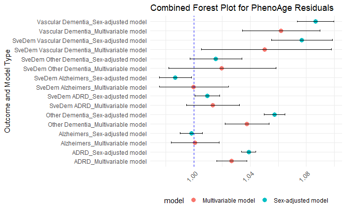

```r
library(ggplot2)
library(dplyr)
library(stringr)

# Assuming the dataframe is named 'your_dataframe'
# Filter for "phenoage_res" and add a unique row identifier combining outcome and model
combined_plot_df <- combined_df_results %>%
  filter(BA == "phenoage_res") %>%
  mutate(unique_id = paste(outcome, model, sep = "_"))

# Creating the combined forest plot
combined_forest_plot <- ggplot(combined_plot_df, aes(y = HR, x = as.factor(unique_id))) +
  geom_point(aes(color = model), size = 3) +
  geom_errorbar(aes(ymin = lb, ymax = ub), width = 0.2, size = 0.7) +
  geom_hline(yintercept = 1, linetype = "dashed", color = "blue", size = 0.7) +
  theme_minimal() +
  labs(title = "Combined Forest Plot for PhenoAge Residuals", y = "Hazard Ratio (HR)", x = "Outcome and Model Type") +
  coord_flip() +
  theme(legend.position = "bottom",
        axis.text.x = element_text(angle = 45, hjust = 1, size = 10),
        axis.title.x = element_blank())

# Display the combined plot
combined_forest_plot
```

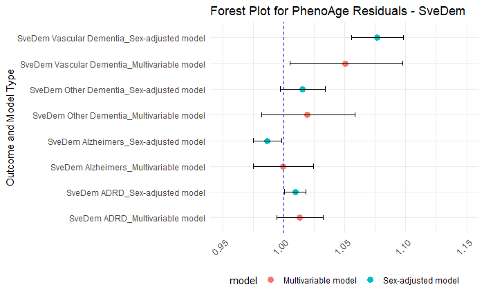

```r
library(ggplot2)
library(dplyr)
library(stringr)

# Assuming your dataframe is named 'combined_df_results'
# Filter for "phenoage_res" and add a unique row identifier combining outcome and model
combined_plot_df <- combined_df_results %>%
  filter(BA == "phenoage_res") %>%
  mutate(unique_id = paste(outcome, model, sep = "_"))

# Filter for outcomes starting with 'S'
outcomes_start_with_S <- combined_plot_df %>%
  filter(str_starts(outcome, "S"))

# Forest plot for outcomes starting with 'S'
forest_plot_S <- ggplot(outcomes_start_with_S, aes(y = HR, x = as.factor(unique_id))) +
  geom_point(aes(color = model), size = 3) +
  geom_errorbar(aes(ymin = lb, ymax = ub), width = 0.2, size = 0.7) +
  geom_hline(yintercept = 1, linetype = "dashed", color = "blue", size = 0.7) +
  theme_minimal() +
  labs(title = "Forest Plot for PhenoAge Residuals - SveDem", y = "Hazard Ratio (HR)", x = "Outcome and Model Type") +
  coord_flip() +
  scale_y_continuous(limits = c(0.95, 1.15)) +
  theme(legend.position = "bottom",
        axis.text.x = element_text(angle = 45, hjust = 1, size = 10),
        axis.title.x = element_blank())

# Display the plot for outcomes starting with 'S'
forest_plot_S
```

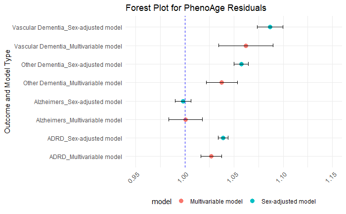

```r
# Filter for outcomes not starting with 'S'
outcomes_not_start_with_S <- combined_plot_df %>%
  filter(!str_starts(outcome, "S"))

# Forest plot for outcomes not starting with 'S'
forest_plot_not_S <- ggplot(outcomes_not_start_with_S, aes(y = HR, x = as.factor(unique_id))) +
  geom_point(aes(color = model), size = 3) +
  geom_errorbar(aes(ymin = lb, ymax = ub), width = 0.2, size = 0.7) +
  geom_hline(yintercept = 1, linetype = "dashed", color = "blue", size = 0.7) +
  theme_minimal() +
  labs(title = "Forest Plot for PhenoAge Residuals", y = "Hazard Ratio (HR)", x = "Outcome and Model Type") +
  coord_flip() +
  scale_y_continuous(limits = c(0.95, 1.15)) +
  theme(legend.position = "bottom",
        axis.text.x = element_text(angle = 45, hjust = 1, size = 10),
        axis.title.x = element_blank())

# Display the plot for outcomes not starting with 'S'
forest_plot_not_S
```

#=========Stratified in a less optimal way - skip this part

```r
# Assuming BA_measures is defined, and you have columns named 'is_man', 'is_woman', 'over_sixtyfive', 'under_sixtyfive' in your data

# Correct the initialization of HR_BA_S_othe data frame
HR_BA_S_othe <- data.frame(
  BA = rep(BA_measures, each = 4),  # 4 for each stratification
  outcome = rep("SveDem other Dementia", times = length(BA_measures) * 4),
  model = rep(c("Stratified: is_man", "Stratified: is_woman", "Stratified: over_sixtyfive", "Stratified: under_sixtyfive"),
              times = length(BA_measures)),
  beta = NA, se = NA, HR = NA, lb = NA, ub = NA, p = NA, p_PH_BA = NA, global_p_PH_BA = NA,
  concordance = NA  # Add a column for the concordance index
)

stratifications <- c("is_man", "is_woman", "over_sixtyfive", "under_sixtyfive")

# Loop over BA measures and stratifications
row_index <- 1
for (j in BA_measures) {
  for (strata in stratifications) {
    fit <- coxph(as.formula(paste("Surv(AgeAtFirstDate, AgeAtLastDate, S_Other) ~", j, "+ strata(", strata, ")")), data = to1po2)
    coef_fit <- summary(fit)

    # Fill in the data frame
    HR_BA_S_othe[row_index, c("beta", "se", "p")] <- coef_fit$coefficients[1, c(1, 3, 5)]
    HR_BA_S_othe[row_index, c("lb", "ub")] <- exp(coef_fit$conf.int[1, c(3, 4)])
    HR_BA_S_othe[row_index, "HR"] <- exp(coef_fit$coefficients[1, "coef"])
    HR_BA_S_othe[row_index, "p_PH_BA"] <- cox.zph(fit)$table[1, 3]
    HR_BA_S_othe[row_index, "global_p_PH_BA"] <- cox.zph(fit)$table[2, 3]
    HR_BA_S_othe[row_index, "concordance"] <- coef_fit$concordance[1]

    row_index <- row_index + 1
  }
}

# Print the data frame
print(HR_BA_S_othe)
```

| BA | outcome | model | beta | se | HR | lb | ub | p | p_PH_BA | global_p_PH_BA | concordance |
| --- | --- | --- | --- | --- | --- | --- | --- | --- | --- | --- | --- |
| kdm_res | SveDem other Dementia | Stratified: is_man | 0.01124359 | 0.006872891 | 1.011307 | 2.712242 | 2.787157 | 1.018535e-01 | 0.201127569 | 0.201127569 | 0.5091728 |
| kdm_res | SveDem other Dementia | Stratified: is_woman | 0.01124359 | 0.006872891 | 1.011307 | 2.712242 | 2.787157 | 1.018535e-01 | 0.201127569 | 0.201127569 | 0.5091728 |
| kdm_res | SveDem other Dementia | Stratified: over_sixtyfive | 0.01155589 | 0.006822330 | 1.011623 | 2.713355 | 2.787766 | 9.029707e-02 | 0.327478924 | 0.327478924 | 0.5130321 |
| kdm_res | SveDem other Dementia | Stratified: under_sixtyfive | 0.01166412 | 0.006824550 | 1.011732 | 2.713637 | 2.788088 | 8.742486e-02 | 0.336976673 | 0.336976673 | 0.5122299 |
| phenoage_res | SveDem other Dementia | Stratified: is_man | 0.08349782 | 0.007257642 | 1.087083 | 2.920424 | 3.012158 | 1.247592e-30 | 0.012722153 | 0.012722153 | 0.5625136 |
| phenoage_res | SveDem other Dementia | Stratified: is_woman | 0.08349782 | 0.007257642 | 1.087083 | 2.920424 | 3.012158 | 1.247592e-30 | 0.012722153 | 0.012722153 | 0.5625136 |
| phenoage_res | SveDem other Dementia | Stratified: over_sixtyfive | 0.07036117 | 0.007151397 | 1.072896 | 2.880495 | 2.968449 | 7.661876e-23 | 0.005086138 | 0.005086138 | 0.5552524 |
| phenoage_res | SveDem other Dementia | Stratified: under_sixtyfive | 0.06930340 | 0.007153486 | 1.071761 | 2.877263 | 2.965050 | 3.389055e-22 | 0.003509094 | 0.003509094 | 0.5545150 |
| hd_log_res | SveDem other Dementia | Stratified: is_man | 0.15069981 | 0.019196185 | 1.162648 | 3.063987 | 3.344189 | 4.143540e-15 | 0.001115826 | 0.001115826 | 0.5444178 |
| hd_log_res | SveDem other Dementia | Stratified: is_woman | 0.15069981 | 0.019196185 | 1.162648 | 3.063987 | 3.344189 | 4.143540e-15 | 0.001115826 | 0.001115826 | 0.5444178 |

[output cut: 2 more lines]

```r
NA
```

#=========================================================================================================

#======== Subgroup analysis ============================================================================== All are based on the gender model

Vanlig vs SveDem

Män vs kvinnor Under 60 vs över 60 Inkomst: låg medium hög Utbildningsnivå: låg vs hög BMI: Låg vs Högt?

## Under 60 vs over 60

ADRD

```r
BA_measures <- c("kdm_res", "phenoage_res", "hd_log_res")

# Initialize HR_BA_adrd data frame
HR_BA <- data.frame(
  BA = rep(BA_measures, each = 2),
  AgeGroup = rep(c("Under 60", "60 and over"), times = length(BA_measures)),
  model = rep("ADRD_agegroup", times = 2 * length(BA_measures)),
  beta = NA, se = NA, HR = NA,
  CI_lower = NA, CI_upper = NA, P_PH_BA = NA, global_p_PH_BA = NA, concordance = NA, N = NA
)

for (j in 1:length(BA_measures)) {
  # Loop over each BA measure
  for (age_group in c("Under 60", "60 and over")) {
    # Subset data based on age group
    if (age_group == "Under 60") {
      data_subset <- to1po2[to1po2$AgeAtLastDate < 60, ]
    } else {
      data_subset <- to1po2[to1po2$AgeAtLastDate >= 60, ]
    }

    # Fit Sex-adjusted model
    fit_gender <- coxph(as.formula(paste("Surv(AgeAtFirstDate, AgeAtLastDate, ADRD) ~", BA_measures[j], "+ gender")), data = data_subset)
    coef_gender <- summary(fit_gender)

    # Determine row index for updating HR_BA
    if (age_group == "Under 60") {
      row_index <- (j - 1) * 2 + 1
    } else {
      row_index <- j * 2
    }

    # Update HR_BA with model results
    HR_BA[row_index, c("beta", "se", "HR")] <- coef_gender$coefficients[1, c(1, 3, 2)]
    HR_BA[row_index, c("CI_lower", "CI_upper")] <- coef_gender$conf.int[1, c(3, 4)]
    HR_BA[row_index, "P_PH_BA"] <- cox.zph(fit_gender)$table[1, 3]
    HR_BA[row_index, "global_p_PH_BA"] <- cox.zph(fit_gender)$table[3, 3]
    HR_BA[row_index, "concordance"] <- coef_gender$concordance[1]
    HR_BA[row_index, "N"] <- coef_gender$n
  }
}
ADRD_agegroup <- HR_BA
# Print the updated HR_BA data frame
print(HR_BA)
```

| BA | AgeGroup | model | beta | se | HR | CI_lower | CI_upper | P_PH_BA | global_p_PH_BA | concordance | N |
| --- | --- | --- | --- | --- | --- | --- | --- | --- | --- | --- | --- |
| kdm_res | Under 60 | ADRD_agegroup | 0.01206040 | 0.007806086 | 1.012133 | 0.996766 | 1.027738 | 3.793741e-01 | 6.427499e-01 | 0.5641278 | 30854 |
| kdm_res | 60 and over | ADRD_agegroup | 0.01373167 | 0.001647710 | 1.013826 | 1.010558 | 1.017106 | 3.829603e-01 | 5.552291e-01 | 0.5095991 | 200888 |
| phenoage_res | Under 60 | ADRD_agegroup | 0.05264436 | 0.010146025 | 1.054055 | 1.033301 | 1.075225 | 1.148103e-01 | 2.332366e-01 | 0.5447638 | 52164 |
| phenoage_res | 60 and over | ADRD_agegroup | 0.03636586 | 0.002540297 | 1.037035 | 1.031885 | 1.042211 | 1.234711e-11 | 2.067043e-11 | 0.5350161 | 207646 |
| hd_log_res | Under 60 | ADRD_agegroup | 0.13959199 | 0.030124972 | 1.149805 | 1.083881 | 1.219738 | 3.618994e-01 | 6.574382e-01 | 0.5431258 | 52164 |
| hd_log_res | 60 and over | ADRD_agegroup | 0.08857443 | 0.007032908 | 1.092616 | 1.077658 | 1.107781 | 1.822920e-08 | 1.255616e-07 | 0.5319755 | 207646 |

```r
NA
```

SveDem ADRD

```r
BA_measures <- c("kdm_res", "phenoage_res", "hd_log_res")

# Initialize HR_BA data frame
HR_BA <- data.frame(
  BA = rep(BA_measures, each = 2),
  AgeGroup = rep(c("Under 60", "60 and over"), times = length(BA_measures)),
  model = rep("S_ADRD_agegroup", times = 2 * length(BA_measures)),
  beta = NA, se = NA, HR = NA,
  CI_lower = NA, CI_upper = NA, P_PH_BA = NA, global_p_PH_BA = NA, concordance = NA, N = NA
)

for (j in 1:length(BA_measures)) {
  # Loop over each BA measure
  for (age_group in c("Under 60", "60 and over")) {
    # Subset data based on age group
    if (age_group == "Under 60") {
      data_subset <- to1po2[to1po2$AgeAtLastDate < 60, ]
    } else {
      data_subset <- to1po2[to1po2$AgeAtLastDate >= 60, ]
    }

    # Fit Sex-adjusted model
    fit_gender <- coxph(as.formula(paste("Surv(AgeAtFirstDate, AgeAtLastDate, S_ADRD_all) ~", BA_measures[j], "+ gender")), data = data_subset)
    coef_gender <- summary(fit_gender)

    # Determine row index for updating HR_BA
    if (age_group == "Under 60") {
      row_index <- (j - 1) * 2 + 1
    } else {
      row_index <- j * 2
    }

    # Update HR_BA with model results
    HR_BA[row_index, c("beta", "se", "HR")] <- coef_gender$coefficients[1, c(1, 3, 2)]
    HR_BA[row_index, c("CI_lower", "CI_upper")] <- coef_gender$conf.int[1, c(3, 4)]
    HR_BA[row_index, "P_PH_BA"] <- cox.zph(fit_gender)$table[1, 3]
    HR_BA[row_index, "global_p_PH_BA"] <- cox.zph(fit_gender)$table[3, 3]
    HR_BA[row_index, "concordance"] <- coef_gender$concordance[1]
    HR_BA[row_index, "N"] <- coef_gender$n
  }
}

S_ADRD_agegroup <- HR_BA

# Print the updated HR_BA data frame
print(HR_BA)
```

| BA | AgeGroup | model | beta | se | HR | CI_lower | CI_upper | P_PH_BA | global_p_PH_BA | concordance | N |
| --- | --- | --- | --- | --- | --- | --- | --- | --- | --- | --- | --- |
| kdm_res | Under 60 | S_ADRD_agegroup | -0.006747204 | 0.027503166 | 0.9932755 | 0.9411503 | 1.048288 | 5.359166e-01 | 6.775063e-01 | 0.4896791 | 30854 |
| kdm_res | 60 and over | S_ADRD_agegroup | 0.013506364 | 0.002785519 | 1.0135980 | 1.0080793 | 1.019147 | 2.439370e-01 | 3.088122e-01 | 0.5162795 | 200888 |
| phenoage_res | Under 60 | S_ADRD_agegroup | 0.014268871 | 0.032842926 | 1.0143712 | 0.9511323 | 1.081815 | 9.157354e-02 | 8.875833e-02 | 0.5209724 | 52164 |
| phenoage_res | 60 and over | S_ADRD_agegroup | 0.008776767 | 0.004547167 | 1.0088154 | 0.9998645 | 1.017846 | 3.850234e-06 | 3.633283e-08 | 0.5158252 | 207646 |
| hd_log_res | Under 60 | S_ADRD_agegroup | -0.027778149 | 0.096928987 | 0.9726041 | 0.8043221 | 1.176094 | 6.342219e-02 | 1.010457e-01 | 0.5466923 | 52164 |
| hd_log_res | 60 and over | S_ADRD_agegroup | 0.058663170 | 0.012365531 | 1.0604180 | 1.0350266 | 1.086432 | 2.245322e-02 | 1.026584e-03 | 0.5224532 | 207646 |

```r
NA
```

Alzheimers

```r
BA_measures <- c("kdm_res", "phenoage_res", "hd_log_res")

# Initialize HR_BA data frame
HR_BA <- data.frame(
  BA = rep(BA_measures, each = 2),
  AgeGroup = rep(c("Under 60", "60 and over"), times = length(BA_measures)),
  model = rep("Alzheimers_agegroup", times = 2 * length(BA_measures)),
  beta = NA, se = NA, HR = NA,
  CI_lower = NA, CI_upper = NA, P_PH_BA = NA, global_p_PH_BA = NA, concordance = NA, N = NA
)

for (j in 1:length(BA_measures)) {
  # Loop over each BA measure
  for (age_group in c("Under 60", "60 and over")) {
    # Subset data based on age group
    if (age_group == "Under 60") {
      data_subset <- to1po2[to1po2$AgeAtLastDate < 60, ]
    } else {
      data_subset <- to1po2[to1po2$AgeAtLastDate >= 60, ]
    }

    # Fit Sex-adjusted model
    fit_gender <- coxph(as.formula(paste("Surv(AgeAtFirstDate, AgeAtLastDate, Alzheimers) ~", BA_measures[j], "+ gender")), data = data_subset)
    coef_gender <- summary(fit_gender)

    # Determine row index for updating HR_BA
    if (age_group == "Under 60") {
      row_index <- (j - 1) * 2 + 1
    } else {
      row_index <- j * 2
    }

    # Update HR_BA with model results
    HR_BA[row_index, c("beta", "se", "HR")] <- coef_gender$coefficients[1, c(1, 3, 2)]
    HR_BA[row_index, c("CI_lower", "CI_upper")] <- coef_gender$conf.int[1, c(3, 4)]
    HR_BA[row_index, "P_PH_BA"] <- cox.zph(fit_gender)$table[1, 3]
    HR_BA[row_index, "global_p_PH_BA"] <- cox.zph(fit_gender)$table[3, 3]
    HR_BA[row_index, "concordance"] <- coef_gender$concordance[1]
    HR_BA[row_index, "N"] <- coef_gender$n
  }
}
Alzheimers_agegroup <- HR_BA

# Print the updated HR_BA data frame
print(HR_BA)
```

| BA | AgeGroup | model | beta | se | HR | CI_lower | CI_upper | P_PH_BA | global_p_PH_BA | concordance | N |
| --- | --- | --- | --- | --- | --- | --- | --- | --- | --- | --- | --- |
| kdm_res | Under 60 | Alzheimers_agegroup | 0.022088147 | 0.021857108 | 1.0223339 | 0.9794628 | 1.0670814 | 0.90723051 | 9.190703e-01 | 0.5537517 | 30854 |
| kdm_res | 60 and over | Alzheimers_agegroup | 0.009910722 | 0.002501972 | 1.0099600 | 1.0050195 | 1.0149248 | 0.16078568 | 1.744423e-03 | 0.5343796 | 200888 |
| phenoage_res | Under 60 | Alzheimers_agegroup | -0.009003313 | 0.029269118 | 0.9910371 | 0.9357848 | 1.0495517 | 0.37424606 | 6.736314e-01 | 0.5239310 | 52164 |
| phenoage_res | 60 and over | Alzheimers_agegroup | -0.002438197 | 0.004114210 | 0.9975648 | 0.9895531 | 1.0056414 | 0.03215161 | 5.922853e-06 | 0.5282789 | 207646 |
| hd_log_res | Under 60 | Alzheimers_agegroup | -0.168318914 | 0.085234855 | 0.8450843 | 0.7150691 | 0.9987391 | 0.14245096 | 3.394345e-01 | 0.5444532 | 52164 |
| hd_log_res | 60 and over | Alzheimers_agegroup | 0.014545309 | 0.011136213 | 1.0146516 | 0.9927452 | 1.0370414 | 0.16785917 | 7.477773e-05 | 0.5325443 | 207646 |

SveDem Alzheimers

```r
BA_measures <- c("kdm_res", "phenoage_res", "hd_log_res")

# Initialize HR_BA data frame
HR_BA <- data.frame(
  BA = rep(BA_measures, each = 2),
  AgeGroup = rep(c("Under 60", "60 and over"), times = length(BA_measures)),
  model = rep("S_Alzheimers_agegroup", times = 2 * length(BA_measures)),
  beta = NA, se = NA, HR = NA,
  CI_lower = NA, CI_upper = NA, P_PH_BA = NA, global_p_PH_BA = NA, concordance = NA, N = NA
)

for (j in 1:length(BA_measures)) {
  # Loop over each BA measure
  for (age_group in c("Under 60", "60 and over")) {
    # Subset data based on age group
    if (age_group == "Under 60") {
      data_subset <- to1po2[to1po2$AgeAtLastDate < 60, ]
    } else {
      data_subset <- to1po2[to1po2$AgeAtLastDate >= 60, ]
    }

    # Fit Sex-adjusted model
    fit_gender <- coxph(as.formula(paste("Surv(AgeAtFirstDate, AgeAtLastDate, S_Alzheimers_all) ~", BA_measures[j], "+ gender")), data = data_subset)
    coef_gender <- summary(fit_gender)

    # Determine row index for updating HR_BA
    if (age_group == "Under 60") {
      row_index <- (j - 1) * 2 + 1
    } else {
      row_index <- j * 2
    }

    # Update HR_BA with model results
    HR_BA[row_index, c("beta", "se", "HR")] <- coef_gender$coefficients[1, c(1, 3, 2)]
    HR_BA[row_index, c("CI_lower", "CI_upper")] <- coef_gender$conf.int[1, c(3, 4)]
    HR_BA[row_index, "P_PH_BA"] <- cox.zph(fit_gender)$table[1, 3]
    HR_BA[row_index, "global_p_PH_BA"] <- cox.zph(fit_gender)$table[3, 3]
    HR_BA[row_index, "concordance"] <- coef_gender$concordance[1]
    HR_BA[row_index, "N"] <- coef_gender$n
  }
}

S_Alzheimers_agegroup <- HR_BA

# Print the updated HR_BA data frame
print(HR_BA)
```

| BA | AgeGroup | model | beta | se | HR | CI_lower | CI_upper | P_PH_BA | global_p_PH_BA | concordance | N |
| --- | --- | --- | --- | --- | --- | --- | --- | --- | --- | --- | --- |
| kdm_res | Under 60 | S_Alzheimers_agegroup | -0.01699310 | 0.043508697 | 0.9831505 | 0.9027870 | 1.0706676 | 0.87517354 | 8.943045e-01 | 0.5121632 | 30854 |
| kdm_res | 60 and over | S_Alzheimers_agegroup | 0.01190737 | 0.003514587 | 1.0119785 | 1.0050315 | 1.0189736 | 0.12118561 | 7.925687e-04 | 0.5416041 | 200888 |
| phenoage_res | Under 60 | S_Alzheimers_agegroup | -0.02475406 | 0.048834908 | 0.9755498 | 0.8865048 | 1.0735389 | 0.39065152 | 4.736668e-01 | 0.5912963 | 52164 |
| phenoage_res | 60 and over | S_Alzheimers_agegroup | -0.01382932 | 0.005997173 | 0.9862659 | 0.9747409 | 0.9979271 | 0.01965169 | 1.158705e-07 | 0.5325667 | 207646 |
| hd_log_res | Under 60 | S_Alzheimers_agegroup | -0.24435289 | 0.142051630 | 0.7832112 | 0.5928766 | 1.0346500 | 0.01976818 | 4.808092e-02 | 0.6104056 | 52164 |
| hd_log_res | 60 and over | S_Alzheimers_agegroup | 0.01981707 | 0.016070246 | 1.0200147 | 0.9883879 | 1.0526536 | 0.30471056 | 2.952623e-06 | 0.5356325 | 207646 |

Vascular

```r
BA_measures <- c("kdm_res", "phenoage_res", "hd_log_res")

# Initialize HR_BA data frame
HR_BA <- data.frame(
  BA = rep(BA_measures, each = 2),
  AgeGroup = rep(c("Under 60", "60 and over"), times = length(BA_measures)),
  model = rep("Vascular_agegroup", times = 2 * length(BA_measures)),
  beta = NA, se = NA, HR = NA,
  CI_lower = NA, CI_upper = NA, P_PH_BA = NA, global_p_PH_BA = NA, concordance = NA, N = NA
)

for (j in 1:length(BA_measures)) {
  # Loop over each BA measure
  for (age_group in c("Under 60", "60 and over")) {
    # Subset data based on age group
    if (age_group == "Under 60") {
      data_subset <- to1po2[to1po2$AgeAtLastDate < 60, ]
    } else {
      data_subset <- to1po2[to1po2$AgeAtLastDate >= 60, ]
    }

    # Fit Sex-adjusted model
    fit_gender <- coxph(as.formula(paste("Surv(AgeAtFirstDate, AgeAtLastDate, Vascular) ~", BA_measures[j], "+ gender")), data = data_subset)
    coef_gender <- summary(fit_gender)

    # Determine row index for updating HR_BA
    if (age_group == "Under 60") {
      row_index <- (j - 1) * 2 + 1
    } else {
      row_index <- j * 2
    }

    # Update HR_BA with model results
    HR_BA[row_index, c("beta", "se", "HR")] <- coef_gender$coefficients[1, c(1, 3, 2)]
    HR_BA[row_index, c("CI_lower", "CI_upper")] <- coef_gender$conf.int[1, c(3, 4)]
    HR_BA[row_index, "P_PH_BA"] <- cox.zph(fit_gender)$table[1, 3]
    HR_BA[row_index, "global_p_PH_BA"] <- cox.zph(fit_gender)$table[3, 3]
    HR_BA[row_index, "concordance"] <- coef_gender$concordance[1]
    HR_BA[row_index, "N"] <- coef_gender$n
  }
}

Vascular_agegroup <- HR_BA
# Print the updated HR_BA data frame
print(HR_BA)
```

| BA | AgeGroup | model | beta | se | HR | CI_lower | CI_upper | P_PH_BA | global_p_PH_BA | concordance | N |
| --- | --- | --- | --- | --- | --- | --- | --- | --- | --- | --- | --- |
| kdm_res | Under 60 | Vascular_agegroup | 0.01818209 | 0.051957256 | 1.018348 | 0.919751 | 1.127515 | 1.787492e-01 | 2.004005e-01 | 0.6169237 | 30854 |
| kdm_res | 60 and over | Vascular_agegroup | 0.01576470 | 0.004304100 | 1.015890 | 1.007356 | 1.024496 | 3.341951e-01 | 1.630606e-05 | 0.5323413 | 200888 |
| phenoage_res | Under 60 | Vascular_agegroup | 0.17408785 | 0.045378831 | 1.190160 | 1.088877 | 1.300864 | 8.164589e-01 | 5.817644e-01 | 0.6817975 | 52164 |
| phenoage_res | 60 and over | Vascular_agegroup | 0.08117026 | 0.006120223 | 1.084556 | 1.071624 | 1.097644 | 4.423530e-10 | 1.868324e-10 | 0.5918692 | 207646 |
| hd_log_res | Under 60 | Vascular_agegroup | 0.36124758 | 0.156459540 | 1.435119 | 1.056110 | 1.950143 | 8.921324e-01 | 6.506056e-01 | 0.6594200 | 52164 |
| hd_log_res | 60 and over | Vascular_agegroup | 0.18713309 | 0.017436655 | 1.205788 | 1.165276 | 1.247708 | 1.196669e-04 | 6.970783e-07 | 0.5808624 | 207646 |

SveDem Vascular ### Prev: Warning: Loglik converged before variable 2 ; beta may be infinite. Error in solve.default(imat, u) : system is computationally singular: reciprocal condition number = 9.67645e-20

```r
BA_measures <- c("kdm_res", "phenoage_res", "hd_log_res")

# Initialize HR_BA data frame
HR_BA <- data.frame(
  BA = rep(BA_measures, each = 2),
  AgeGroup = rep(c("Under 60", "60 and over"), times = length(BA_measures)),
  model = rep("S_Vascular_agegroup", times = 2 * length(BA_measures)),
  beta = NA, se = NA, HR = NA,
  CI_lower = NA, CI_upper = NA, P_PH_BA = NA, global_p_PH_BA = NA, concordance = NA, N = NA
)

for (j in 1:length(BA_measures)) {
  # Loop over each BA measure
  for (age_group in c("Under 60", "60 and over")) {
    # Subset data based on age group
    if (age_group == "Under 60") {
      data_subset <- to1po2[to1po2$AgeAtLastDate < 60, ]
    } else {
      data_subset <- to1po2[to1po2$AgeAtLastDate >= 60, ]
    }

    # Fit Sex-adjusted model
    fit_gender <- coxph(as.formula(paste("Surv(AgeAtFirstDate, AgeAtLastDate, S_Vascular_all) ~", BA_measures[j], "+ gender")), data = data_subset)
    coef_gender <- summary(fit_gender)

    # Determine row index for updating HR_BA
    if (age_group == "Under 60") {
      row_index <- (j - 1) * 2 + 1
    } else {
      row_index <- j * 2
    }

    # Update HR_BA with model results
    HR_BA[row_index, c("beta", "se", "HR")] <- coef_gender$coefficients[1, c(1, 3, 2)]
    HR_BA[row_index, c("CI_lower", "CI_upper")] <- coef_gender$conf.int[1, c(3, 4)]
    HR_BA[row_index, "P_PH_BA"] <- cox.zph(fit_gender)$table[1, 3]
    HR_BA[row_index, "global_p_PH_BA"] <- cox.zph(fit_gender)$table[3, 3]
    HR_BA[row_index, "concordance"] <- coef_gender$concordance[1]
    HR_BA[row_index, "N"] <- coef_gender$n
  }
}

S_Vascular_agegroup <- HR_BA
# Print the updated HR_BA data frame
print(HR_BA)
```

| BA | AgeGroup | model | beta | se | HR | CI_lower | CI_upper | P_PH_BA | global_p_PH_BA | concordance | N |
| --- | --- | --- | --- | --- | --- | --- | --- | --- | --- | --- | --- |
| kdm_res | Under 60 | S_Vascular_agegroup | 0.02276435 | 0.084420907 | 1.023025 | 0.8670162 | 1.207107 | 0.5938714618 | 0.450978321 | 0.5973960 | 30854 |
| kdm_res | 60 and over | S_Vascular_agegroup | 0.01155386 | 0.007055172 | 1.011621 | 0.9977286 | 1.025707 | 0.8242762625 | 0.320155588 | 0.5251133 | 200888 |
| phenoage_res | Under 60 | S_Vascular_agegroup | 0.01991869 | 0.098764130 | 1.020118 | 0.8405865 | 1.237995 | 0.1862666941 | 0.157461000 | 0.5596536 | 52164 |
| phenoage_res | 60 and over | S_Vascular_agegroup | 0.07425609 | 0.010262414 | 1.077083 | 1.0556346 | 1.098966 | 0.0004604334 | 0.002164511 | 0.5862256 | 207646 |
| hd_log_res | Under 60 | S_Vascular_agegroup | 0.45138555 | 0.269196204 | 1.570487 | 0.9266037 | 2.661794 | 0.8404819271 | 0.569341952 | 0.6456936 | 52164 |
| hd_log_res | 60 and over | S_Vascular_agegroup | 0.15195081 | 0.029157173 | 1.164103 | 1.0994431 | 1.232566 | 0.0991660331 | 0.193499236 | 0.5690291 | 207646 |

```r
BA_measures <- c("kdm_res")

# Initialize HR_BA data frame
HR_BA <- data.frame(
  BA = rep(BA_measures, each = 2),
  AgeGroup = rep(c("Under 60", "60 and over"), times = length(BA_measures)),
  model = rep("S_Vascular_agegroup", times = 2 * length(BA_measures)),
  beta = NA, se = NA, HR = NA,
  CI_lower = NA, CI_upper = NA, P_PH_BA = NA, global_p_PH_BA = NA, concordance = NA, N = NA
)

for (j in 1:length(BA_measures)) {
  # Loop over each BA measure
  for (age_group in c("Under 60", "60 and over")) {
    # Subset data based on age group
    if (age_group == "Under 60") {
      data_subset <- to1po2[to1po2$AgeAtLastDate < 60, ]
    } else {
      data_subset <- to1po2[to1po2$AgeAtLastDate >= 60, ]
    }

    # Fit Sex-adjusted model
    fit_gender <- coxph(as.formula(paste("Surv(AgeAtFirstDate, AgeAtLastDate, S_Vascular_all) ~", BA_measures[j], "+ gender")), data = data_subset)
    coef_gender <- summary(fit_gender)

    # Determine row index for updating HR_BA
    if (age_group == "Under 60") {
      row_index <- (j - 1) * 2 + 1
    } else {
      row_index <- j * 2
    }

    # Update HR_BA with model results
    HR_BA[row_index, c("beta", "se", "HR")] <- coef_gender$coefficients[1, c(1, 3, 2)]
    HR_BA[row_index, c("CI_lower", "CI_upper")] <- coef_gender$conf.int[1, c(3, 4)]
    HR_BA[row_index, "P_PH_BA"] <- cox.zph(fit_gender)$table[1, 3]
    HR_BA[row_index, "global_p_PH_BA"] <- cox.zph(fit_gender)$table[3, 3]
    HR_BA[row_index, "concordance"] <- coef_gender$concordance[1]
    HR_BA[row_index, "N"] <- coef_gender$n
  }
}

S_Vascular_agegroup <- HR_BA
# Print the updated HR_BA data frame
print(HR_BA)
```

| BA | AgeGroup | model | beta | se | HR | CI_lower | CI_upper | P_PH_BA | global_p_PH_BA | concordance | N |
| --- | --- | --- | --- | --- | --- | --- | --- | --- | --- | --- | --- |
| kdm_res | Under 60 | S_Vascular_agegroup | 0.02276435 | 0.084420907 | 1.023025 | 0.8670162 | 1.207107 | 0.5938715 | 0.4509783 | 0.5973960 | 30854 |
| kdm_res | 60 and over | S_Vascular_agegroup | 0.01155386 | 0.007055172 | 1.011621 | 0.9977286 | 1.025707 | 0.8242763 | 0.3201556 | 0.5251133 | 200888 |

Other Dementia

```r
BA_measures <- c("kdm_res", "phenoage_res", "hd_log_res")

# Initialize HR_BA data frame
HR_BA <- data.frame(
  BA = rep(BA_measures, each = 2),
  AgeGroup = rep(c("Under 60", "60 and over"), times = length(BA_measures)),
  model = rep("Other_agegroup", times = 2 * length(BA_measures)),
  beta = NA, se = NA, HR = NA,
  CI_lower = NA, CI_upper = NA, P_PH_BA = NA, global_p_PH_BA = NA, concordance = NA, N = NA
)

for (j in 1:length(BA_measures)) {
  # Loop over each BA measure
  for (age_group in c("Under 60", "60 and over")) {
    # Subset data based on age group
    if (age_group == "Under 60") {
      data_subset <- to1po2[to1po2$AgeAtLastDate < 60, ]
    } else {
      data_subset <- to1po2[to1po2$AgeAtLastDate >= 60, ]
    }

    # Fit Sex-adjusted model
    fit_gender <- coxph(as.formula(paste("Surv(AgeAtFirstDate, AgeAtLastDate, Other) ~", BA_measures[j], "+ gender")), data = data_subset)
    coef_gender <- summary(fit_gender)

    # Determine row index for updating HR_BA
    if (age_group == "Under 60") {
      row_index <- (j - 1) * 2 + 1
    } else {
      row_index <- j * 2
    }

    # Update HR_BA with model results
    HR_BA[row_index, c("beta", "se", "HR")] <- coef_gender$coefficients[1, c(1, 3, 2)]
    HR_BA[row_index, c("CI_lower", "CI_upper")] <- coef_gender$conf.int[1, c(3, 4)]
    HR_BA[row_index, "P_PH_BA"] <- cox.zph(fit_gender)$table[1, 3]
    HR_BA[row_index, "global_p_PH_BA"] <- cox.zph(fit_gender)$table[3, 3]
    HR_BA[row_index, "concordance"] <- coef_gender$concordance[1]
    HR_BA[row_index, "N"] <- coef_gender$n
  }
}

Other_agegroup <- HR_BA

# Print the updated HR_BA data frame
print(HR_BA)
```

| BA | AgeGroup | model | beta | se | HR | CI_lower | CI_upper | P_PH_BA | global_p_PH_BA | concordance | N |
| --- | --- | --- | --- | --- | --- | --- | --- | --- | --- | --- | --- |
| kdm_res | Under 60 | Other_agegroup | 0.01045338 | 0.008467331 | 1.010508 | 0.9938765 | 1.027418 | 3.106626e-01 | 5.964907e-01 | 0.5694472 | 30854 |
| kdm_res | 60 and over | Other_agegroup | 0.01690089 | 0.002545491 | 1.017045 | 1.0119831 | 1.022131 | 5.067220e-01 | 1.027222e-01 | 0.5151327 | 200888 |
| phenoage_res | Under 60 | Other_agegroup | 0.05583963 | 0.011119505 | 1.057428 | 1.0346320 | 1.080726 | 7.535406e-02 | 1.090464e-01 | 0.5511215 | 52164 |
| phenoage_res | 60 and over | Other_agegroup | 0.05433944 | 0.003796875 | 1.055843 | 1.0480148 | 1.063730 | 1.345775e-07 | 8.277977e-07 | 0.5501889 | 207646 |
| hd_log_res | Under 60 | Other_agegroup | 0.17772227 | 0.032838074 | 1.194494 | 1.1200360 | 1.273901 | 4.586392e-01 | 6.658434e-01 | 0.5523566 | 52164 |
| hd_log_res | 60 and over | Other_agegroup | 0.12072187 | 0.010616535 | 1.128311 | 1.1050757 | 1.152035 | 4.708910e-07 | 7.422814e-07 | 0.5450167 | 207646 |

SveDem Other

```r
BA_measures <- c("kdm_res", "phenoage_res", "hd_log_res")

# Initialize HR_BA data frame
HR_BA <- data.frame(
  BA = rep(BA_measures, each = 2),
  AgeGroup = rep(c("Under 60", "60 and over"), times = length(BA_measures)),
  model = rep("S_Other_agegroup", times = 2 * length(BA_measures)),
  beta = NA, se = NA, HR = NA,
  CI_lower = NA, CI_upper = NA, P_PH_BA = NA, global_p_PH_BA = NA, concordance = NA, N = NA
)

for (j in 1:length(BA_measures)) {
  # Loop over each BA measure
  for (age_group in c("Under 60", "60 and over")) {
    # Subset data based on age group
    if (age_group == "Under 60") {
      data_subset <- to1po2[to1po2$AgeAtLastDate < 60, ]
    } else {
      data_subset <- to1po2[to1po2$AgeAtLastDate >= 60, ]
    }

    # Fit Sex-adjusted model
    fit_gender <- coxph(as.formula(paste("Surv(AgeAtFirstDate, AgeAtLastDate, S_other_all) ~", BA_measures[j], "+ gender")), data = data_subset)
    coef_gender <- summary(fit_gender)

    # Determine row index for updating HR_BA
    if (age_group == "Under 60") {
      row_index <- (j - 1) * 2 + 1
    } else {
      row_index <- j * 2
    }

    # Update HR_BA with model results
    HR_BA[row_index, c("beta", "se", "HR")] <- coef_gender$coefficients[1, c(1, 3, 2)]
    HR_BA[row_index, c("CI_lower", "CI_upper")] <- coef_gender$conf.int[1, c(3, 4)]
    HR_BA[row_index, "P_PH_BA"] <- cox.zph(fit_gender)$table[1, 3]
    HR_BA[row_index, "global_p_PH_BA"] <- cox.zph(fit_gender)$table[3, 3]
    HR_BA[row_index, "concordance"] <- coef_gender$concordance[1]
    HR_BA[row_index, "N"] <- coef_gender$n
  }
}

S_Other_agegroup <- HR_BA

# Print the updated HR_BA data frame
print(HR_BA)
```

| BA | AgeGroup | model | beta | se | HR | CI_lower | CI_upper | P_PH_BA | global_p_PH_BA | concordance | N |
| --- | --- | --- | --- | --- | --- | --- | --- | --- | --- | --- | --- |
| kdm_res | Under 60 | S_Other_agegroup | -0.004445807 | 0.039043631 | 0.9955641 | 0.9222214 | 1.074739 | 0.167101843 | 0.38062748 | 0.5118703 | 30854 |
| kdm_res | 60 and over | S_Other_agegroup | 0.019611265 | 0.005992086 | 1.0198048 | 1.0078980 | 1.031852 | 0.646255389 | 0.08816854 | 0.5218676 | 200888 |
| phenoage_res | Under 60 | S_Other_agegroup | 0.056758593 | 0.049415513 | 1.0584003 | 0.9606991 | 1.166037 | 0.289585919 | 0.44246775 | 0.5150619 | 52164 |
| phenoage_res | 60 and over | S_Other_agegroup | 0.013375581 | 0.009475419 | 1.0134654 | 0.9948176 | 1.032463 | 0.003920294 | 0.01133376 | 0.5279108 | 207646 |
| hd_log_res | Under 60 | S_Other_agegroup | 0.084334849 | 0.149780515 | 1.0879931 | 0.8112090 | 1.459216 | 0.691432092 | 0.84027021 | 0.5120415 | 52164 |
| hd_log_res | 60 and over | S_Other_agegroup | 0.086930559 | 0.025849739 | 1.0908209 | 1.0369316 | 1.147511 | 0.122305494 | 0.14762833 | 0.5406355 | 207646 |

===

## Sex

```r
# Copy 'gender' to 'new_gender'
to1po2$new_gender <- to1po2$gender
# Check unique values in the original 'gender' column
unique(to1po2$gender)
```

```
[1] "1" "2"
```

```r
# Convert 'new_gender' to factor with correct levels
# Assuming the unique values are "1" for men and "2" for women
to1po2$new_gender <- factor(to1po2$new_gender, levels = c("1", "2"), labels = c("Men", "Women"))
# Verify the conversion
table(to1po2$new_gender)
```

```
   Men  Women
134997 124813
```

ADRD

```r
BA_measures <- c("kdm_res", "phenoage_res", "hd_log_res")

# Initialize HR_BA data frame
HR_BA <- data.frame(
  BA = rep(BA_measures, each = 2),
  Gender = rep(c("Men", "Women"), times = length(BA_measures)),
  model = rep("ADRD_sex", times = 2 * length(BA_measures)),
  beta = NA, se = NA, HR = NA,
  CI_lower = NA, CI_upper = NA, P_PH_BA = NA, global_p_PH_BA = NA, concordance = NA, N = NA
)

for (j in 1:length(BA_measures)) {
  for (gender_group in c("Men", "Women")) {
    # Subset data based on new_sex
    data_subset <- to1po2[to1po2$new_gender == gender_group, ]

    # Fit Cox model for the BA measure (without 'new_gender' as a covariate)
    fit_gender <- coxph(as.formula(paste("Surv(AgeAtFirstDate, AgeAtLastDate, ADRD) ~", BA_measures[j])), data = data_subset)
    coef_gender <- summary(fit_gender)

    # Determine row index for updating HR_BA
    row_index <- if (gender_group == "Men") (j - 1) * 2 + 1 else j * 2

    # Update HR_BA with model results
    HR_BA[row_index, c("beta", "se", "HR")] <- coef_gender$coefficients[1, c(1, 3, 2)]
    HR_BA[row_index, c("CI_lower", "CI_upper")] <- coef_gender$conf.int[1, c(3, 4)]
    HR_BA[row_index, "P_PH_BA"] <- cox.zph(fit_gender)$table[1, 3]
    HR_BA[row_index, "global_p_PH_BA"] <- cox.zph(fit_gender)$table[2, 3]
    HR_BA[row_index, "concordance"] <- coef_gender$concordance[1]
    HR_BA[row_index, "N"] <- coef_gender$n
  }
}
ADRD_gender <- HR_BA
# Print the updated HR_BA data frame
print(HR_BA)
```

| BA | Gender | model | beta | se | HR | CI_lower | CI_upper | P_PH_BA | global_p_PH_BA | concordance | N |
| --- | --- | --- | --- | --- | --- | --- | --- | --- | --- | --- | --- |
| kdm_res | Men | ADRD_sex | -0.06497093 | 0.009629909 | 0.9370947 | 0.9195736 | 0.9549497 | 8.071154e-03 | 8.071154e-03 | 0.5224459 | 122720 |
| kdm_res | Women | ADRD_sex | 0.01604442 | 0.001629203 | 1.0161738 | 1.0129342 | 1.0194238 | 1.607906e-01 | 1.607906e-01 | 0.5283024 | 109022 |
| phenoage_res | Men | ADRD_sex | 0.04929322 | 0.003649246 | 1.0505283 | 1.0430414 | 1.0580691 | 4.466198e-09 | 4.466198e-09 | 0.5460148 | 134997 |
| phenoage_res | Women | ADRD_sex | 0.02981346 | 0.003345068 | 1.0302623 | 1.0235298 | 1.0370391 | 5.995815e-06 | 5.995815e-06 | 0.5286887 | 124813 |
| hd_log_res | Men | ADRD_sex | 0.10913758 | 0.010269036 | 1.1153158 | 1.0930923 | 1.1379911 | 2.635251e-09 | 2.635251e-09 | 0.5400565 | 134997 |
| hd_log_res | Women | ADRD_sex | 0.08154492 | 0.009162041 | 1.0849620 | 1.0656529 | 1.1046209 | 2.216235e-03 | 2.216235e-03 | 0.5257274 | 124813 |

ADRD SveDem

```r
BA_measures <- c("kdm_res", "phenoage_res", "hd_log_res")

# Initialize HR_BA data frame
HR_BA <- data.frame(
  BA = rep(BA_measures, each = 2),
  Gender = rep(c("Men", "Women"), times = length(BA_measures)),
  model = rep("S_ADRD_sex", times = 2 * length(BA_measures)),
  beta = NA, se = NA, HR = NA,
  CI_lower = NA, CI_upper = NA, P_PH_BA = NA, global_p_PH_BA = NA, concordance = NA, N = NA
)

for (j in 1:length(BA_measures)) {
  for (gender_group in c("Men", "Women")) {
    # Subset data based on new_gender
    data_subset <- to1po2[to1po2$new_gender == gender_group, ]

    # Fit Cox model for the BA measure (without 'new_gender' as a covariate)
    fit_gender <- coxph(as.formula(paste("Surv(AgeAtFirstDate, AgeAtLastDate, S_ADRD_all) ~", BA_measures[j])), data = data_subset)
    coef_gender <- summary(fit_gender)

    # Determine row index for updating HR_BA
    row_index <- if (gender_group == "Men") (j - 1) * 2 + 1 else j * 2

    # Update HR_BA with model results
    HR_BA[row_index, c("beta", "se", "HR")] <- coef_gender$coefficients[1, c(1, 3, 2)]
    HR_BA[row_index, c("CI_lower", "CI_upper")] <- coef_gender$conf.int[1, c(3, 4)]
    HR_BA[row_index, "P_PH_BA"] <- cox.zph(fit_gender)$table[1, 3]
    HR_BA[row_index, "global_p_PH_BA"] <- cox.zph(fit_gender)$table[2, 3]
    HR_BA[row_index, "concordance"] <- coef_gender$concordance[1]
    HR_BA[row_index, "N"] <- coef_gender$n
  }
}

S_ADRD_gender <- HR_BA

# Print the updated HR_BA data frame
print(HR_BA)
```

| BA | Gender | model | beta | se | HR | CI_lower | CI_upper | P_PH_BA | global_p_PH_BA | concordance | N |
| --- | --- | --- | --- | --- | --- | --- | --- | --- | --- | --- | --- |
| kdm_res | Men | S_ADRD_sex | -0.116437063 | 0.016669909 | 0.8900861 | 0.8614748 | 0.9196477 | 1.826879e-01 | 1.826879e-01 | 0.5252829 | 122720 |
| kdm_res | Women | S_ADRD_sex | 0.016977105 | 0.002797995 | 1.0171220 | 1.0115594 | 1.0227152 | 2.840220e-01 | 2.840220e-01 | 0.5313459 | 109022 |
| phenoage_res | Men | S_ADRD_sex | 0.026740686 | 0.006577335 | 1.0271014 | 1.0139457 | 1.0404279 | 1.128977e-02 | 1.128977e-02 | 0.5310986 | 134997 |
| phenoage_res | Women | S_ADRD_sex | -0.003862209 | 0.006196860 | 0.9961452 | 0.9841196 | 1.0083178 | 1.557457e-05 | 1.557457e-05 | 0.4965676 | 124813 |
| hd_log_res | Men | S_ADRD_sex | 0.066390321 | 0.018219320 | 1.0686437 | 1.0311566 | 1.1074937 | 1.188640e-02 | 1.188640e-02 | 0.5275700 | 134997 |
| hd_log_res | Women | S_ADRD_sex | 0.053968986 | 0.016577174 | 1.0554519 | 1.0217106 | 1.0903074 | 4.834435e-01 | 4.834435e-01 | 0.5176301 | 124813 |

Alzheimers

```r
BA_measures <- c("kdm_res", "phenoage_res", "hd_log_res")

# Initialize HR_BA data frame
HR_BA <- data.frame(
  BA = rep(BA_measures, each = 2),
  Gender = rep(c("Men", "Women"), times = length(BA_measures)),
  model = rep("Alzheimers_sex", times = 2 * length(BA_measures)),
  beta = NA, se = NA, HR = NA,
  CI_lower = NA, CI_upper = NA, P_PH_BA = NA, global_p_PH_BA = NA, concordance = NA, N = NA
)

for (j in 1:length(BA_measures)) {
  for (gender_group in c("Men", "Women")) {
    # Subset data based on new_gender
    data_subset <- to1po2[to1po2$new_gender == gender_group, ]

    # Fit Cox model for the BA measure (without 'new_gender' as a covariate)
    fit_gender <- coxph(as.formula(paste("Surv(AgeAtFirstDate, AgeAtLastDate, Alzheimers) ~", BA_measures[j])), data = data_subset)
    coef_gender <- summary(fit_gender)

    # Determine row index for updating HR_BA
    row_index <- if (gender_group == "Men") (j - 1) * 2 + 1 else j * 2

    # Update HR_BA with model results
    HR_BA[row_index, c("beta", "se", "HR")] <- coef_gender$coefficients[1, c(1, 3, 2)]
    HR_BA[row_index, c("CI_lower", "CI_upper")] <- coef_gender$conf.int[1, c(3, 4)]
    HR_BA[row_index, "P_PH_BA"] <- cox.zph(fit_gender)$table[1, 3]
    HR_BA[row_index, "global_p_PH_BA"] <- cox.zph(fit_gender)$table[2, 3]
    HR_BA[row_index, "concordance"] <- coef_gender$concordance[1]
    HR_BA[row_index, "N"] <- coef_gender$n
  }
}

Alzheimers_gender <- HR_BA

# Print the updated HR_BA data frame
print(HR_BA)
```

| BA | Gender | model | beta | se | HR | CI_lower | CI_upper | P_PH_BA | global_p_PH_BA | concordance | N |
| --- | --- | --- | --- | --- | --- | --- | --- | --- | --- | --- | --- |
| kdm_res | Men | Alzheimers_sex | -0.046647715 | 0.015928341 | 0.9544236 | 0.9250877 | 0.9846897 | 0.61839051 | 0.61839051 | 0.5120313 | 122720 |
| kdm_res | Women | Alzheimers_sex | 0.011409916 | 0.002512446 | 1.0114753 | 1.0065067 | 1.0164684 | 0.09060191 | 0.09060191 | 0.5222561 | 109022 |
| phenoage_res | Men | Alzheimers_sex | 0.004023136 | 0.006267277 | 1.0040312 | 0.9917735 | 1.0164405 | 0.04498489 | 0.04498489 | 0.5087087 | 134997 |
| phenoage_res | Women | Alzheimers_sex | -0.004665081 | 0.005369251 | 0.9953458 | 0.9849261 | 1.0058757 | 0.04952156 | 0.04952156 | 0.5015114 | 124813 |
| hd_log_res | Men | Alzheimers_sex | 0.021633038 | 0.017188461 | 1.0218687 | 0.9880167 | 1.0568807 | 0.33291258 | 0.33291258 | 0.5089346 | 134997 |
| hd_log_res | Women | Alzheimers_sex | 0.008456886 | 0.014398602 | 1.0084927 | 0.9804302 | 1.0373586 | 0.61427541 | 0.61427541 | 0.5018672 | 124813 |

Alzheimers SveDem

```r
BA_measures <- c("kdm_res", "phenoage_res", "hd_log_res")

# Initialize HR_BA data frame
HR_BA <- data.frame(
  BA = rep(BA_measures, each = 2),
  Gender = rep(c("Men", "Women"), times = length(BA_measures)),
  model = rep("S_Alzheimers_sex", times = 2 * length(BA_measures)),
  beta = NA, se = NA, HR = NA,
  CI_lower = NA, CI_upper = NA, P_PH_BA = NA, global_p_PH_BA = NA, concordance = NA, N = NA
)

for (j in 1:length(BA_measures)) {
  for (gender_group in c("Men", "Women")) {
    # Subset data based on new_gender
    data_subset <- to1po2[to1po2$new_gender == gender_group, ]

    # Fit Cox model for the BA measure (without 'new_gender' as a covariate)
    fit_gender <- coxph(as.formula(paste("Surv(AgeAtFirstDate, AgeAtLastDate, S_Alzheimers_all) ~", BA_measures[j])), data = data_subset)
    coef_gender <- summary(fit_gender)

    # Determine row index for updating HR_BA
    row_index <- if (gender_group == "Men") (j - 1) * 2 + 1 else j * 2

    # Update HR_BA with model results
    HR_BA[row_index, c("beta", "se", "HR")] <- coef_gender$coefficients[1, c(1, 3, 2)]
    HR_BA[row_index, c("CI_lower", "CI_upper")] <- coef_gender$conf.int[1, c(3, 4)]
    HR_BA[row_index, "P_PH_BA"] <- cox.zph(fit_gender)$table[1, 3]
    HR_BA[row_index, "global_p_PH_BA"] <- cox.zph(fit_gender)$table[2, 3]
    HR_BA[row_index, "concordance"] <- coef_gender$concordance[1]
    HR_BA[row_index, "N"] <- coef_gender$n
  }
}

S_Alzheimers_gender <- HR_BA

# Print the updated HR_BA data frame
print(HR_BA)
```

| BA | Gender | model | beta | se | HR | CI_lower | CI_upper | P_PH_BA | global_p_PH_BA | concordance | N |
| --- | --- | --- | --- | --- | --- | --- | --- | --- | --- | --- | --- |
| kdm_res | Men | S_Alzheimers_sex | -0.071147518 | 0.022571617 | 0.9313245 | 0.8910212 | 0.9734508 | 0.14472571 | 0.14472571 | 0.5093631 | 122720 |
| kdm_res | Women | S_Alzheimers_sex | 0.013647123 | 0.003539809 | 1.0137407 | 1.0067318 | 1.0207984 | 0.18619322 | 0.18619322 | 0.5253067 | 109022 |
| phenoage_res | Men | S_Alzheimers_sex | -0.001876707 | 0.009066265 | 0.9981251 | 0.9805455 | 1.0160198 | 0.07164366 | 0.07164366 | 0.4902431 | 134997 |
| phenoage_res | Women | S_Alzheimers_sex | -0.019081255 | 0.007906118 | 0.9810996 | 0.9660140 | 0.9964209 | 0.01566108 | 0.01566108 | 0.5129224 | 124813 |
| hd_log_res | Men | S_Alzheimers_sex | 0.021769239 | 0.024686797 | 1.0220079 | 0.9737351 | 1.0726739 | 0.91734617 | 0.91734617 | 0.5076751 | 134997 |
| hd_log_res | Women | S_Alzheimers_sex | 0.018246239 | 0.020944405 | 1.0184137 | 0.9774540 | 1.0610898 | 0.35931515 | 0.35931515 | 0.5065357 | 124813 |

Vascular

```r
BA_measures <- c("kdm_res", "phenoage_res", "hd_log_res")

# Initialize HR_BA data frame
HR_BA <- data.frame(
  BA = rep(BA_measures, each = 2),
  Gender = rep(c("Men", "Women"), times = length(BA_measures)),
  model = rep("Vascular_sex", times = 2 * length(BA_measures)),
  beta = NA, se = NA, HR = NA,
  CI_lower = NA, CI_upper = NA, P_PH_BA = NA, global_p_PH_BA = NA, concordance = NA, N = NA
)

for (j in 1:length(BA_measures)) {
  for (gender_group in c("Men", "Women")) {
    # Subset data based on new_gender
    data_subset <- to1po2[to1po2$new_gender == gender_group, ]

    # Fit Cox model for the BA measure (without 'new_gender' as a covariate)
    fit_gender <- coxph(as.formula(paste("Surv(AgeAtFirstDate, AgeAtLastDate, Vascular) ~", BA_measures[j])), data = data_subset)
    coef_gender <- summary(fit_gender)

    # Determine row index for updating HR_BA
    row_index <- if (gender_group == "Men") (j - 1) * 2 + 1 else j * 2

    # Update HR_BA with model results
    HR_BA[row_index, c("beta", "se", "HR")] <- coef_gender$coefficients[1, c(1, 3, 2)]
    HR_BA[row_index, c("CI_lower", "CI_upper")] <- coef_gender$conf.int[1, c(3, 4)]
    HR_BA[row_index, "P_PH_BA"] <- cox.zph(fit_gender)$table[1, 3]
    HR_BA[row_index, "global_p_PH_BA"] <- cox.zph(fit_gender)$table[2, 3]
    HR_BA[row_index, "concordance"] <- coef_gender$concordance[1]
    HR_BA[row_index, "N"] <- coef_gender$n
  }
}

Vascular_gender <- HR_BA

# Print the updated HR_BA data frame
print(HR_BA)
```

| BA | Gender | model | beta | se | HR | CI_lower | CI_upper | P_PH_BA | global_p_PH_BA | concordance | N |
| --- | --- | --- | --- | --- | --- | --- | --- | --- | --- | --- | --- |
| kdm_res | Men | Vascular_sex | -0.20260545 | 0.022434481 | 0.8166004 | 0.7814718 | 0.853308 | 6.132163e-04 | 6.132163e-04 | 0.5727785 | 122720 |
| kdm_res | Women | Vascular_sex | 0.02413158 | 0.004323429 | 1.0244251 | 1.0157810 | 1.033143 | 9.461337e-01 | 9.461337e-01 | 0.5499671 | 109022 |
| phenoage_res | Men | Vascular_sex | 0.10031468 | 0.008303561 | 1.1055187 | 1.0876724 | 1.123658 | 7.580130e-06 | 7.580130e-06 | 0.5961678 | 134997 |
| phenoage_res | Women | Vascular_sex | 0.06078957 | 0.008938969 | 1.0626753 | 1.0442193 | 1.081457 | 6.022607e-04 | 6.022607e-04 | 0.5648481 | 124813 |
| hd_log_res | Men | Vascular_sex | 0.22246816 | 0.023928285 | 1.2491560 | 1.1919249 | 1.309135 | 6.340893e-05 | 6.340893e-05 | 0.5772697 | 134997 |
| hd_log_res | Women | Vascular_sex | 0.15081091 | 0.025025219 | 1.1627768 | 1.1071204 | 1.221231 | 1.573268e-01 | 1.573268e-01 | 0.5523708 | 124813 |

SveDem Vascular

```r
BA_measures <- c("kdm_res", "phenoage_res", "hd_log_res")

# Initialize HR_BA data frame
HR_BA <- data.frame(
  BA = rep(BA_measures, each = 2),
  Gender = rep(c("Men", "Women"), times = length(BA_measures)),
  model = rep("S_Vascular_sex", times = 2 * length(BA_measures)),
  beta = NA, se = NA, HR = NA,
  CI_lower = NA, CI_upper = NA, P_PH_BA = NA, global_p_PH_BA = NA, concordance = NA, N = NA
)

for (j in 1:length(BA_measures)) {
  for (gender_group in c("Men", "Women")) {
    # Subset data based on new_gender
    data_subset <- to1po2[to1po2$new_gender == gender_group, ]

    # Fit Cox model for the BA measure (without 'new_gender' as a covariate)
    fit_gender <- coxph(as.formula(paste("Surv(AgeAtFirstDate, AgeAtLastDate, S_Vascular_all) ~", BA_measures[j])), data = data_subset)
    coef_gender <- summary(fit_gender)

    # Determine row index for updating HR_BA
    row_index <- if (gender_group == "Men") (j - 1) * 2 + 1 else j * 2

    # Update HR_BA with model results
    HR_BA[row_index, c("beta", "se", "HR")] <- coef_gender$coefficients[1, c(1, 3, 2)]
    HR_BA[row_index, c("CI_lower", "CI_upper")] <- coef_gender$conf.int[1, c(3, 4)]
    HR_BA[row_index, "P_PH_BA"] <- cox.zph(fit_gender)$table[1, 3]
    HR_BA[row_index, "global_p_PH_BA"] <- cox.zph(fit_gender)$table[2, 3]
    HR_BA[row_index, "concordance"] <- coef_gender$concordance[1]
    HR_BA[row_index, "N"] <- coef_gender$n
  }
}

S_Vascular_gender <- HR_BA

# Print the updated HR_BA data frame
print(HR_BA)
```

| BA | Gender | model | beta | se | HR | CI_lower | CI_upper | P_PH_BA | global_p_PH_BA | concordance | N |
| --- | --- | --- | --- | --- | --- | --- | --- | --- | --- | --- | --- |
| kdm_res | Men | S_Vascular_sex | -0.27889916 | 0.036462568 | 0.7566162 | 0.7044313 | 0.812667 | 0.519551040 | 0.519551040 | 0.5820930 | 122720 |
| kdm_res | Women | S_Vascular_sex | 0.02244565 | 0.007067904 | 1.0226994 | 1.0086298 | 1.036965 | 0.471885580 | 0.471885580 | 0.5520437 | 109022 |
| phenoage_res | Men | S_Vascular_sex | 0.09780735 | 0.013845854 | 1.1027503 | 1.0732270 | 1.133086 | 0.189998387 | 0.189998387 | 0.5901314 | 134997 |
| phenoage_res | Women | S_Vascular_sex | 0.04594555 | 0.015154420 | 1.0470174 | 1.0163761 | 1.078582 | 0.003701136 | 0.003701136 | 0.5541543 | 124813 |
| hd_log_res | Men | S_Vascular_sex | 0.19262797 | 0.039906070 | 1.2124316 | 1.1212157 | 1.311068 | 0.012841798 | 0.012841798 | 0.5729614 | 134997 |
| hd_log_res | Women | S_Vascular_sex | 0.11398787 | 0.042031954 | 1.1207385 | 1.0321116 | 1.216976 | 0.891206738 | 0.891206738 | 0.5405852 | 124813 |

Other

```r
BA_measures <- c("kdm_res", "phenoage_res", "hd_log_res")

# Initialize HR_BA data frame
HR_BA <- data.frame(
  BA = rep(BA_measures, each = 2),
  Gender = rep(c("Men", "Women"), times = length(BA_measures)),
  model = rep("Other_sex", times = 2 * length(BA_measures)),
  beta = NA, se = NA, HR = NA,
  CI_lower = NA, CI_upper = NA, P_PH_BA = NA, global_p_PH_BA = NA, concordance = NA, N = NA
)

for (j in 1:length(BA_measures)) {
  for (gender_group in c("Men", "Women")) {
    # Subset data based on new_gender
    data_subset <- to1po2[to1po2$new_gender == gender_group, ]

    # Fit Cox model for the BA measure (without 'new_gender' as a covariate)
    fit_gender <- coxph(as.formula(paste("Surv(AgeAtFirstDate, AgeAtLastDate, Other) ~", BA_measures[j])), data = data_subset)
    coef_gender <- summary(fit_gender)

    # Determine row index for updating HR_BA
    row_index <- if (gender_group == "Men") (j - 1) * 2 + 1 else j * 2

    # Update HR_BA with model results
    HR_BA[row_index, c("beta", "se", "HR")] <- coef_gender$coefficients[1, c(1, 3, 2)]
    HR_BA[row_index, c("CI_lower", "CI_upper")] <- coef_gender$conf.int[1, c(3, 4)]
    HR_BA[row_index, "P_PH_BA"] <- cox.zph(fit_gender)$table[1, 3]
    HR_BA[row_index, "global_p_PH_BA"] <- cox.zph(fit_gender)$table[2, 3]
    HR_BA[row_index, "concordance"] <- coef_gender$concordance[1]
    HR_BA[row_index, "N"] <- coef_gender$n
  }
}

Other_gender <- HR_BA

# Print the updated HR_BA data frame
print(HR_BA)
```

| BA | Gender | model | beta | se | HR | CI_lower | CI_upper | P_PH_BA | global_p_PH_BA | concordance | N |
| --- | --- | --- | --- | --- | --- | --- | --- | --- | --- | --- | --- |
| kdm_res | Men | Other_sex | -0.02459210 | 0.014341643 | 0.9757078 | 0.9486634 | 1.003523 | 1.431424e-01 | 1.431424e-01 | 0.5116905 | 122720 |
| kdm_res | Women | Other_sex | 0.01791163 | 0.002465042 | 1.0180730 | 1.0131662 | 1.023004 | 5.273619e-01 | 5.273619e-01 | 0.5283165 | 109022 |
| phenoage_res | Men | Other_sex | 0.06323223 | 0.005321105 | 1.0652742 | 1.0542220 | 1.076442 | 8.673421e-05 | 8.673421e-05 | 0.5559743 | 134997 |
| phenoage_res | Women | Other_sex | 0.05035884 | 0.004866517 | 1.0516484 | 1.0416653 | 1.061727 | 3.233471e-04 | 3.233471e-04 | 0.5480815 | 124813 |
| hd_log_res | Men | Other_sex | 0.13359953 | 0.015141508 | 1.1429350 | 1.1095147 | 1.177362 | 7.200668e-07 | 7.200668e-07 | 0.5501498 | 134997 |
| hd_log_res | Women | Other_sex | 0.12631918 | 0.013495772 | 1.1346443 | 1.1050250 | 1.165057 | 3.994460e-04 | 3.994460e-04 | 0.5416430 | 124813 |

SveDem Other

```r
BA_measures <- c("kdm_res", "phenoage_res", "hd_log_res")

# Initialize HR_BA data frame
HR_BA <- data.frame(
  BA = rep(BA_measures, each = 2),
  Gender = rep(c("Men", "Women"), times = length(BA_measures)),
  model = rep("S_Other_sex", times = 2 * length(BA_measures)),
  beta = NA, se = NA, HR = NA,
  CI_lower = NA, CI_upper = NA, P_PH_BA = NA, global_p_PH_BA = NA, concordance = NA, N = NA
)

for (j in 1:length(BA_measures)) {
  for (gender_group in c("Men", "Women")) {
    # Subset data based on new_gender
    data_subset <- to1po2[to1po2$new_gender == gender_group, ]

    # Fit Cox model for the BA measure (without 'new_gender' as a covariate)
    fit_gender <- coxph(as.formula(paste("Surv(AgeAtFirstDate, AgeAtLastDate, S_other_all) ~", BA_measures[j])), data = data_subset)
    coef_gender <- summary(fit_gender)

    # Determine row index for updating HR_BA
    row_index <- if (gender_group == "Men") (j - 1) * 2 + 1 else j * 2

    # Update HR_BA with model results
    HR_BA[row_index, c("beta", "se", "HR")] <- coef_gender$coefficients[1, c(1, 3, 2)]
    HR_BA[row_index, c("CI_lower", "CI_upper")] <- coef_gender$conf.int[1, c(3, 4)]
    HR_BA[row_index, "P_PH_BA"] <- cox.zph(fit_gender)$table[1, 3]
    HR_BA[row_index, "global_p_PH_BA"] <- cox.zph(fit_gender)$table[2, 3]
    HR_BA[row_index, "concordance"] <- coef_gender$concordance[1]
    HR_BA[row_index, "N"] <- coef_gender$n
  }
}

S_Other_gender <- HR_BA

# Print the updated HR_BA data frame
print(HR_BA)
```

| BA | Gender | model | beta | se | HR | CI_lower | CI_upper | P_PH_BA | global_p_PH_BA | concordance | N |
| --- | --- | --- | --- | --- | --- | --- | --- | --- | --- | --- | --- |
| kdm_res | Men | S_Other_sex | -0.082341228 | 0.033524463 | 0.9209576 | 0.8623897 | 0.9835031 | 0.335871077 | 0.335871077 | 0.5156851 | 122720 |
| kdm_res | Women | S_Other_sex | 0.022680923 | 0.005985399 | 1.0229401 | 1.0110099 | 1.0350110 | 0.581032365 | 0.581032365 | 0.5355588 | 109022 |
| phenoage_res | Men | S_Other_sex | 0.027816873 | 0.013129155 | 1.0282074 | 1.0020864 | 1.0550093 | 0.319843974 | 0.319843974 | 0.5300769 | 134997 |
| phenoage_res | Women | S_Other_sex | 0.002897333 | 0.013236665 | 1.0029015 | 0.9772175 | 1.0292606 | 0.002857824 | 0.002857824 | 0.5177608 | 124813 |
| hd_log_res | Men | S_Other_sex | 0.060740990 | 0.036582328 | 1.0626236 | 0.9891008 | 1.1416117 | 0.004342308 | 0.004342308 | 0.5333011 | 134997 |
| hd_log_res | Women | S_Other_sex | 0.114266132 | 0.035484210 | 1.1210504 | 1.0457333 | 1.2017922 | 0.945283128 | 0.945283128 | 0.5344298 | 124813 |

Bind the subgroups for agegroup and gender

```r
# Add a new column to each data frame indicating the source
ADRD_agegroup$Source <- "ADRD_agegroup"
S_ADRD_agegroup$Source <- "S_ADRD_agegroup"
Alzheimers_agegroup$Source <- "Alzheimers_agegroup"
S_Alzheimers_agegroup$Source <- "S_Alzheimers_agegroup"
Vascular_agegroup$Source <- "Vascular_agegroup"
S_Vascular_agegroup$Source <- "S_Vascular_agegroup"
Other_agegroup$Source <- "Other_agegroup"
S_Other_agegroup$Source <- "S_Other_agegroup"

# Combine all data frames into one large data frame
combined_df_agegroup <- rbind(
  ADRD_agegroup,
  S_ADRD_agegroup,
  Alzheimers_agegroup,
  S_Alzheimers_agegroup,
  Vascular_agegroup,
  S_Vascular_agegroup,
  Other_agegroup,
  S_Other_agegroup
)

# View the combined data frame
head(combined_df_agegroup)
```

|  | BA | AgeGroup | model | beta | se | HR | CI_lower | CI_upper | P_PH_BA | global_p_PH_BA | concordance | N | Source |
| --- | --- | --- | --- | --- | --- | --- | --- | --- | --- | --- | --- | --- | --- |
| 1 | kdm_res | Under 60 | ADRD_agegroup | 0.01206040 | 0.007806086 | 1.012133 | 0.996766 | 1.027738 | 3.793741e-01 | 6.427499e-01 | 0.5641278 | 30854 | ADRD_agegroup |
| 2 | kdm_res | 60 and over | ADRD_agegroup | 0.01373167 | 0.001647710 | 1.013826 | 1.010558 | 1.017106 | 3.829603e-01 | 5.552291e-01 | 0.5095991 | 200888 | ADRD_agegroup |
| 3 | phenoage_res | Under 60 | ADRD_agegroup | 0.05264436 | 0.010146025 | 1.054055 | 1.033301 | 1.075225 | 1.148103e-01 | 2.332366e-01 | 0.5447638 | 52164 | ADRD_agegroup |
| 4 | phenoage_res | 60 and over | ADRD_agegroup | 0.03636586 | 0.002540297 | 1.037035 | 1.031885 | 1.042211 | 1.234711e-11 | 2.067043e-11 | 0.5350161 | 207646 | ADRD_agegroup |
| 5 | hd_log_res | Under 60 | ADRD_agegroup | 0.13959199 | 0.030124972 | 1.149805 | 1.083881 | 1.219738 | 3.618994e-01 | 6.574382e-01 | 0.5431258 | 52164 | ADRD_agegroup |
| 6 | hd_log_res | 60 and over | ADRD_agegroup | 0.08857443 | 0.007032908 | 1.092616 | 1.077658 | 1.107781 | 1.822920e-08 | 1.255616e-07 | 0.5319755 | 207646 | ADRD_agegroup |

```r
# Add a new column 'Source' to each data frame
ADRD_gender$Source <- "ADRD"
S_ADRD_gender$Source <- "S_ADRD"
Alzheimers_gender$Source <- "Alzheimers"
S_Alzheimers_gender$Source <- "S_Alzheimers"
Vascular_gender$Source <- "Vascular"
S_Vascular_gender$Source <- "S_Vascular"
Other_gender$Source <- "Other"
S_Other_gender$Source <- "S_Other"

# Combine all data frames into one large data frame
combined_df_gender <- rbind(
  ADRD_gender,
  S_ADRD_gender,
  Alzheimers_gender,
  S_Alzheimers_gender,
  Vascular_gender,
  S_Vascular_gender,
  Other_gender,
  S_Other_gender
)

# View the combined data frame
head(combined_df_gender)
```

|  | BA | Gender | model | beta | se | HR | CI_lower | CI_upper | P_PH_BA | global_p_PH_BA | concordance | N | Source |
| --- | --- | --- | --- | --- | --- | --- | --- | --- | --- | --- | --- | --- | --- |
| 1 | kdm_res | Men | ADRD_sex | -0.06497093 | 0.009629909 | 0.9370947 | 0.9195736 | 0.9549497 | 8.071154e-03 | 8.071154e-03 | 0.5224459 | 122720 | ADRD |
| 2 | kdm_res | Women | ADRD_sex | 0.01604442 | 0.001629203 | 1.0161738 | 1.0129342 | 1.0194238 | 1.607906e-01 | 1.607906e-01 | 0.5283024 | 109022 | ADRD |
| 3 | phenoage_res | Men | ADRD_sex | 0.04929322 | 0.003649246 | 1.0505283 | 1.0430414 | 1.0580691 | 4.466198e-09 | 4.466198e-09 | 0.5460148 | 134997 | ADRD |
| 4 | phenoage_res | Women | ADRD_sex | 0.02981346 | 0.003345068 | 1.0302623 | 1.0235298 | 1.0370391 | 5.995815e-06 | 5.995815e-06 | 0.5286887 | 124813 | ADRD |
| 5 | hd_log_res | Men | ADRD_sex | 0.10913758 | 0.010269036 | 1.1153158 | 1.0930923 | 1.1379911 | 2.635251e-09 | 2.635251e-09 | 0.5400565 | 134997 | ADRD |
| 6 | hd_log_res | Women | ADRD_sex | 0.08154492 | 0.009162041 | 1.0849620 | 1.0656529 | 1.1046209 | 2.216235e-03 | 2.216235e-03 | 0.5257274 | 124813 | ADRD |

```r
NA
NA
```

#================================================================

#==============Forest plots======================================

## Subgroup age

```r
library(ggplot2)
library(dplyr)
library(stringr)

# Filtering and adding a unique row identifier
filtered_df_agegroup <- combined_df_agegroup %>%
  filter(BA == "phenoage_res") %>%
  mutate(unique_id = paste(model, AgeGroup, sep = "_")) %>%
  # Renaming the AgeGroup categories
  mutate(AgeGroup = ifelse(AgeGroup == "Under 60", "Below 60", "60 and Above"))

# Re-check the unique values in the AgeGroup column
unique_values <- unique(filtered_df_agegroup$AgeGroup)
print(unique_values)
```

```
[1] "Below 60"     "60 and Above"
```

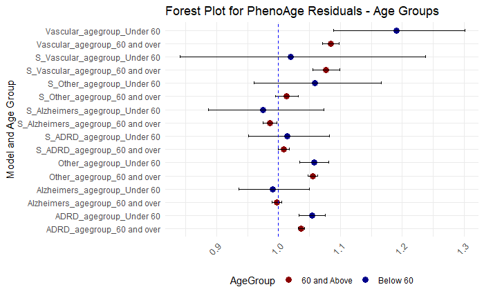

```r
# Forest plot with the renamed age groups
forest_plot_agegroup <- ggplot(filtered_df_agegroup, aes(y = HR, x = as.factor(unique_id))) +
  geom_point(aes(color = AgeGroup), size = 3) +
  geom_errorbar(aes(ymin = CI_lower, ymax = CI_upper), width = 0.2, size = 0.7) +
  geom_hline(yintercept = 1, linetype = "dashed", color = "blue", size = 0.7) +
  scale_color_manual(values = c("Below 60" = "darkblue", "60 and Above" = "darkred")) +
  theme_minimal() +
  labs(title = "Forest Plot for PhenoAge Residuals - Age Groups", y = "Hazard Ratio (HR)", x = "Model and Age Group") +
  coord_flip() +
  theme(legend.position = "bottom",
        axis.text.x = element_text(angle = 45, hjust = 1, size = 10),
        axis.title.x = element_blank())

# Display the plot
forest_plot_agegroup
```

```r
NA
NA
```

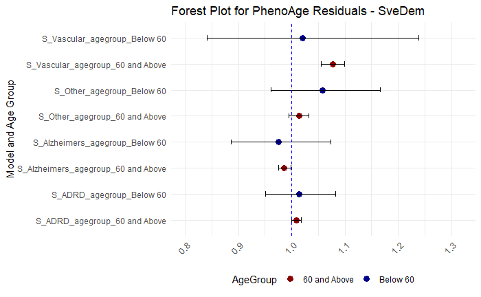

```r
library(ggplot2)
library(dplyr)
library(stringr)

# Renaming the AgeGroup categories and adding a unique row identifier
filtered_df_agegroup <- combined_df_agegroup %>%
  filter(BA == "phenoage_res") %>%
  mutate(AgeGroup = ifelse(AgeGroup == "Under 60", "Below 60", "60 and Above")) %>%
  mutate(unique_id = paste(model, AgeGroup, sep = "_"))

# Filter for models starting with 'S'
models_start_with_S <- filtered_df_agegroup %>%
  filter(str_starts(model, "S"))

# Filter for models not starting with 'S'
models_not_start_with_S <- filtered_df_agegroup %>%
  filter(!str_starts(model, "S"))

# Forest Plot for Models Starting with 'S'
forest_plot_S <- ggplot(models_start_with_S, aes(y = HR, x = as.factor(unique_id))) +
  geom_point(aes(color = AgeGroup), size = 3) +
  geom_errorbar(aes(ymin = CI_lower, ymax = CI_upper), width = 0.2, size = 0.7) +
  geom_hline(yintercept = 1, linetype = "dashed", color = "blue", size = 0.7) +
  scale_color_manual(values = c("Below 60" = "darkblue", "60 and Above" = "darkred")) +
  theme_minimal() +
  labs(title = "Forest Plot for PhenoAge Residuals - SveDem", y = "Hazard Ratio (HR)", x = "Model and Age Group") +
  coord_flip() +
  scale_y_continuous(limits = c(0.8, 1.32)) + # Set limits here
  theme(legend.position = "bottom",
        axis.text.x = element_text(angle = 45, hjust = 1, size = 10),
        axis.title.x = element_blank())

# Display the plot for models starting with 'S'
forest_plot_S
```

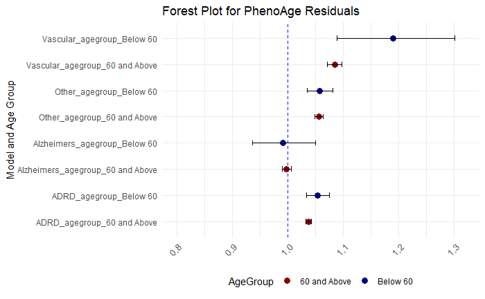

```r
# Forest Plot for Models Not Starting with 'S'
forest_plot_not_S <- ggplot(models_not_start_with_S, aes(y = HR, x = as.factor(unique_id))) +
  geom_point(aes(color = AgeGroup), size = 3) +
  geom_errorbar(aes(ymin = CI_lower, ymax = CI_upper), width = 0.2, size = 0.7) +
  geom_hline(yintercept = 1, linetype = "dashed", color = "blue", size = 0.7) +
  scale_color_manual(values = c("Below 60" = "darkblue", "60 and Above" = "darkred")) +
  theme_minimal() +
  labs(title = "Forest Plot for PhenoAge Residuals", y = "Hazard Ratio (HR)", x = "Model and Age Group") +
  coord_flip() +
  scale_y_continuous(limits = c(0.8, 1.32)) + # Set limits here
  theme(legend.position = "bottom",
        axis.text.x = element_text(angle = 45, hjust = 1, size = 10),
        axis.title.x = element_blank())

# Display the plot for models not starting with 'S'
forest_plot_not_S
```

```r
NA
NA
```